# How to read this book

## 7.7 Build the First Click Game

Now put everything into one page.

```html
<!doctype html>
<html lang="en">
<head>
  <meta charset="utf-8">
  <title>Click the Monster</title>
</head>
<body>
  <h1>Click the Monster!</h1>

  <button id="monster">Monster</button>
  <p id="message">Can you catch it?</p>

  <script>
    const monster = document.getElementById("monster");
    const message = document.getElementById("message");

    function hitMonster() {
      message.textContent = "Great hit!";
    }

    monster.addEventListener("click", hitMonster);
  </script>
</body>
</html>
```

[figure not shown]

Structure: HTML only, before CSS or JavaScript.

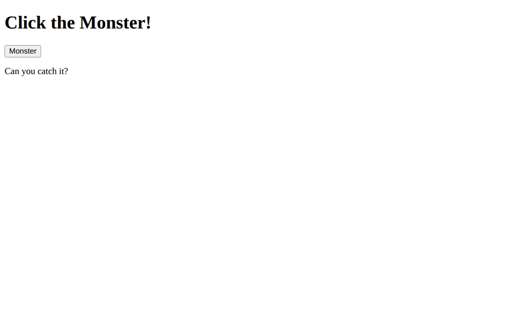

Style check: this example has no custom CSS, so its appearance still uses browser defaults.

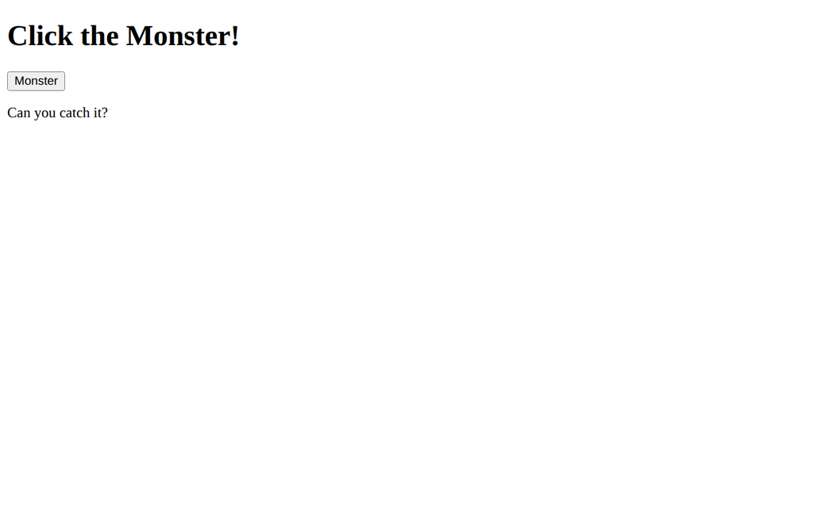

Behavior before input: the message asks Can you catch it?

[figure not shown]

After clicking the monster, the event handler changes the message to Great hit!

### What happens when the page opens?

The browser:

1. reads the HTML;
2. builds DOM elements for the heading, button, and paragraph;
3. reaches the `<script>`;
4. finds the `monster` and `message` DOM elements;
5. creates the `hitMonster` function;
6. attaches a click listener to the monster;
7. enters the waiting phase.

Nothing says “Great hit!” yet because the handler has not been called. The browser is waiting for a click event.

### What happens when the player clicks?

The browser:

1. detects a `click` event on the monster;
2. sees that a click listener is attached;
3. runs `hitMonster()`;
4. changes `message.textContent`;
5. redraws the page with the new message.

That is your first event-driven game interaction.

## 7.8 A Picture Can Receive Events Too

A click event is not only for buttons.

Any DOM element can receive events, including an image.

```html
<img id="gem" src="gem.svg" alt="Purple game gem" width="96">
<p id="message">Click the gem.</p>
```

JavaScript can find the image:

```javascript
const gem = document.getElementById("gem");
const message = document.getElementById("message");
```

Then listen for its click:

```javascript
function collectGem() {
  message.textContent = "You collected the gem!";
}

gem.addEventListener("click", collectGem);
```

The important idea is not “buttons can be clicked.”

The important idea is:

> JavaScript can find a DOM element and listen for events on that element.

That is much more powerful. Later, game characters, cards, menu items, pictures, and parts of a game screen can all become interactive.

## 7.9 One Mental Model to Remember

If this chapter feels like many new words, remember this simple model:

`{mermaid} flowchart LR A[HTML element] --> B[DOM element] B --> C[JavaScript gets it] D[Player action] --> E[Event] E --> F[Event listener] F --> G[Function runs] G --> H[DOM changes]`

Or say it in one sentence:

> **JavaScript gets a DOM element, listens for an event, and changes the page when that event happens.**

Advanced Study: What If JavaScript Cannot Find the Element?

If this code cannot find a matching element:

```javascript
const monster = document.getElementById("monster");
```

JavaScript receives a special value called `null`.

This can happen when:

- the ID is misspelled;
- the element does not have that ID;
- JavaScript runs before the browser has created that element.

For now, keep the `<script>` near the bottom of `<body>`, after the elements your JavaScript needs. That way, the browser creates those DOM elements before JavaScript searches for them.

## Exercises

Use **Structure → Style → Behavior** as a check before each task. The focus below identifies the stage you are practicing. For reading or prediction tasks, trace or explain the result; you do not need a new page or visual redesign.

### Exercise 1: Element or Event?

**Flow focus:** Structure + Behavior: separate a scene part from the event that can act on it.

For each item, write **element** or **event**.

1. a button
2. a paragraph
3. a click
4. an image
5. a key press

### Exercise 2: Match the HTML and JavaScript

**Flow focus:** Structure + Behavior: match the existing scene IDs to the code that finds them.

Given this HTML:

```html
<button id="dragon">Dragon</button>
<p id="status">Ready!</p>
```

Complete the JavaScript:

```javascript
const dragon = document.getElementById("________");
const status = document.getElementById("________");
```

### Exercise 3: Read the DOM Lookup

**Flow focus:** Program game behavior: explain how this operation selects one existing scene part.

Explain this line in plain English:

```javascript
const treasure = document.getElementById("treasure");
```

### Exercise 4: Predict Before You Run

**Flow focus:** Program game behavior: predict the response on the existing button and message; keep their style.

What will the player see after clicking the button?

```html
<button id="door">Open Door</button>
<p id="message">The door is closed.</p>

<script>
  const door = document.getElementById("door");
  const message = document.getElementById("message");

  function openDoor() {
    message.textContent = "The door is open!";
  }

  door.addEventListener("click", openDoor);
</script>
```

### Exercise 5: Find the Bug

**Flow focus:** Structure + Behavior: check the element identity before changing the event code.

Why does this code fail to find the button?

```html
<button id="monster">Monster</button>
```

```javascript
const monster = document.getElementById("Monster");
```

Fix the JavaScript.

### Exercise 6: Trace the Event Flow

**Flow focus:** Program game behavior: trace one action from input to visible feedback.

Put these steps in the correct order:

- `hitMonster` changes the message.
- The browser detects a click.
- The player clicks the monster.
- The event listener tells the browser which function to run.
- The player sees the changed message.

### Exercise 7: Follow the ID Connection

**Flow focus:** Structure + Behavior: verify each scene identity and its exact lookup spelling.

For each pair, decide whether `getElementById()` will find the element.

```html
<img id="star" src="star.png">
```

```javascript
document.getElementById("star")
```

```html
<button id="startGame">Start</button>
```

```javascript
document.getElementById("start")
```

```html
<p id="Score">0</p>
```

```javascript
document.getElementById("score")
```

Explain why each one does or does not match.

### Exercise 8: Sequential or Event-Driven?

**Flow focus:** Program game behavior: distinguish setting up an action from performing it later.

For each statement, decide whether it belongs to the **setup phase** or happens **later because of an event**.

1. `getElementById("monster")` runs when the page script starts.
2. The player waits three seconds and clicks the monster.
3. `hitMonster` runs because the click occurred.
4. `addEventListener()` connects the click to `hitMonster`.
5. The browser waits for another event.

### Exercise 9: Same Pattern, New Event

**Flow focus:** Program game behavior: identify the input event and the operation it will trigger.

Look at this code:

```javascript
document.addEventListener("keydown", movePlayer);
```

Identify:

1. the object receiving the listener;
2. the event type;
3. the handler function;
4. when `movePlayer` runs.

## Challenges

### Challenge 1: Change the Character

**Structure:** Replace the visible character and give it the intended ID. **Style:** Keep or choose a recognizable character appearance. **Behavior:** Update the matching lookup and response, then perform one click.

Change the monster into a dragon, robot, ghost, or another character.

You must change:

- the visible HTML;
- the element’s `id`;
- the matching `getElementById()` call;
- the response message.

### Challenge 2: Two Clickable Game Objects

**Structure:** Add two distinct objects and their message area, each object with its own ID. **Style:** Make the objects recognizable and their targets easy to use. **Behavior:** Connect separate responses and test each object.

Create two buttons or images.

For example:

- a monster;
- a treasure chest.

Give each element its own ID, event listener, and response function.

### Challenge 3: Build a Choice Game

**Structure:** Create both door choices and one message area. **Style:** Make the choice labels and red/blue identity clear. **Behavior:** Connect each choice to its response and test both paths.

Create two choices such as:

- **Open the red door**
- **Open the blue door**

When the player clicks each choice, show a different message.

Use the same four-part pattern:

```
Get element → Listen for click → Run function → Change DOM
```

### Challenge 4: Explain Your Game Like a Programmer

**Structure:** Identify the object, its element, and its ID. **Style:** Describe the visual cue that helps the player recognize it. **Behavior:** Explain the lookup, event, handler, and visible result in order.

Choose one clickable object from your game and explain:

1. which HTML element represents it;
2. which ID identifies it;
3. how JavaScript gets its DOM element;
4. which event the program listens for;
5. which function runs;
6. which DOM element changes after the event.

# 8 Let the Monster Clicker Make Decisions

GAME 08 | Monster Clicker: Decisions

Branches Comparisons Game Rules

## Overview

Now the game needs something new: **rules**.

A real game does not always do the same thing. It asks questions:

- Is the score high enough for a power move?
- Has the player reached a new level?
- Has the player won?
- Should the game show encouragement or a victory message?

JavaScript answers these questions with **conditions** and **branches**. A branch lets the program choose one path or another.

`{mermaid} flowchart LR A[Player clicks monster] --> B[Score changes] B --> C{What is the score?} C -->|Less than 5| D[Keep going!] C -->|5 to 9| E[Monster is nervous!] C -->|10 or more| F[You win!]`

The game is still the same project. We are not throwing away Chapters 6 and 7. We are **upgrading** them.

## Learning Objectives

By the end of this chapter, you will be able to:

- explain what a **condition** is;
- use comparison operators such as `===`, `<`, `>`, `<=`, and `>=`;
- write an `if` statement;
- choose between two paths with `if` and `else`;
- choose among several paths with `if`, `else if`, and `else`;
- use branches to create rules for the Monster Clicker game.

Structure → Style → Behavior

**Build the scene structure → Style the scene → Program game behavior.**

- **Build the scene structure:** Identify the monster, special-action controls, score, and message; add a control only if the rule needs one.
- **Style the scene:** Make action labels, costs, and success/refusal messages easy to distinguish.
- **Behavior:** Implement the conditions and score changes, then test below, at, and above each threshold.

Use this plan for the examples and exercises below. Reuse parts that already work; change only what the task needs. After each step, predict one result and check it.

## 8.1 From Memory to Decisions

```javascript
let score = 0;

function hitMonster() {
  score = score + 1;
  scoreText.textContent = "Score: " + score;
}
```

Every click does exactly the same thing:

1. add 1 to `score`;
2. show the new score.

But suppose you want the game to say **“You reached 5 hits!”** when the score reaches 5.

Now the program must ask a question:

> Is the score equal to 5?

That kind of yes-or-no question is called a **condition**.

## 8.2 Conditions Become `true` or `false`

A condition is an expression that JavaScript can answer with either:

- `true` — yes;
- `false` — no.

For example:

```javascript
score === 5
```

If `score` is 5, this condition is `true`.

If `score` is 3, this condition is `false`.

Important: `=` and `===` Have Different Jobs

These symbols look similar, but they do different jobs.

```javascript
score = 5;      // store 5 in score
score === 5     // ask: is score equal to 5?
```

Use `=` to **assign** a value.

Use `===` to **compare** values.

Here are several useful comparison operators:

| Operator | Meaning | Example |
| --- | --- | --- |
| `===` | equal to | `score === 5` |
| `!==` | not equal to | `score !== 5` |
| `>` | greater than | `score > 5` |
| `<` | less than | `score < 5` |
| `>=` | greater than or equal to | `score >= 5` |
| `<=` | less than or equal to | `score <= 5` |

Try It: Predict Before Running

Suppose `score` is 7. Decide whether each condition is `true` or `false`.

```javascript
score === 7
score > 10
score >= 5
score < 7
score !== 3
```

## 8.3 Your First Branch with `if`

An `if` statement tells JavaScript:

> If this condition is true, run this code.

```javascript
if (score === 5) {
  message.textContent = "You reached 5 hits!";
}
```

Read it from top to bottom:

1. `if` starts a decision.
2. `(score === 5)` is the condition.
3. `{` and `}` surround the code that belongs to this branch.
4. The message changes only when the condition is `true`.

Add it to the Monster Clicker:

```javascript
function hitMonster() {
  score = score + 1;
  scoreText.textContent = "Score: " + score;

  if (score === 5) {
    message.textContent = "You reached 5 hits!";
  }
}
```

Now the game behaves differently on one special click.

`{mermaid} flowchart TD A[Monster clicked] --> B[Add 1 to score] B --> C{score === 5?} C -->|Yes| D[Show milestone message] C -->|No| E[Do nothing extra]`

Watch Out: The Condition Goes Inside Parentheses

Write:

```javascript
if (score === 5) {
```

not:

```javascript
if score === 5 {
```

JavaScript needs the parentheses around the condition.

## 8.4 Choose Between Two Paths with `if` and `else`

Sometimes the game should do one thing when a condition is true and something different when it is false.

Suppose the monster should react differently before and after 5 hits.

```javascript
if (score < 5) {
  message.textContent = "Keep clicking!";
} else {
  message.textContent = "The monster is getting nervous!";
}
```

There are now two possible paths:

`{mermaid} flowchart LR A{score < 5?} -->|Yes| B[Keep clicking!] A -->|No| C[Monster is getting nervous!]`

Notice that `else` does not need another condition. It means:

> If the first condition was false, do this instead.

### 8.4.1 Put it into the click function

```javascript
function hitMonster() {
  score = score + 1;
  scoreText.textContent = "Score: " + score;

  if (score < 5) {
    message.textContent = "Keep clicking!";
  } else {
    message.textContent = "The monster is getting nervous!";
  }
}
```

This is already more game-like because the response changes as the player makes progress.

## 8.5 Choose Among Several Paths with `else if`

Games often need more than two choices.

For our Monster Clicker, let us create three stages:

- score 1–4: **Keep clicking!**
- score 5–9: **The monster is getting nervous!**
- score 10 or more: **You win!**

Use `else if` for the middle choice:

```javascript
if (score < 5) {
  message.textContent = "Keep clicking!";
} else if (score < 10) {
  message.textContent = "The monster is getting nervous!";
} else {
  message.textContent = "You win!";
}
```

JavaScript checks the branches **from top to bottom**.

If `score` is 3:

1. `score < 5` is true;
2. JavaScript uses the first branch;
3. it skips the rest.

If `score` is 7:

1. `score < 5` is false;
2. `score < 10` is true;
3. JavaScript uses the second branch.

If `score` is 12:

1. `score < 5` is false;
2. `score < 10` is false;
3. `else` runs.

Why Does the Middle Branch Mean 5 Through 9?

Look at this code again:

```javascript
if (score < 5) {
  // 0 through 4
} else if (score < 10) {
  // 5 through 9
}
```

The second branch is checked only after JavaScript already knows that `score < 5` is false.

So when JavaScript reaches `score < 10`, the score must already be 5 or more.

That is why the middle branch covers 5 through 9.

## 8.6 Use a Branch to Enforce a Game Rule

Imagine a **Power Hit** costs 5 points.

The game should ask:

> Does the player have at least 5 points?

```javascript
if (score >= 5) {
  score = score - 5;
  message.textContent = "POWER HIT! You spent 5 points.";
} else {
  message.textContent = "You need 5 points for a Power Hit.";
}
```

This branch protects the game rule. The score cannot drop below zero because subtraction happens only when `score >= 5` is true.

Game Design Idea

A branch is more than JavaScript syntax. It is how you turn a **game rule** into code.

Rule in words:

> A Power Hit costs 5 points.

Rule in JavaScript:

```javascript
if (score >= 5) {
  score = score - 5;
}
```

## 8.7 Build the Complete Game: Monster Clicker with Levels

Now combine what you built across three chapters.

COMPLETE EXAMPLE

```html
<!doctype html>
<html>
<body>
  <h1>Monster Clicker</h1>

  <button id="monster">Hit the monster</button>
  <button id="power">⚡ Power Hit (-5 points)</button>

  <p id="score">Score: 0</p>
  <p id="message">Start clicking the monster!</p>

  <script>
    let score = 0;

    const monster = document.getElementById("monster");
    const power = document.getElementById("power");
    const scoreText = document.getElementById("score");
    const message = document.getElementById("message");

    function showGameState() {
      scoreText.textContent = "Score: " + score;

      if (score < 5) {
        message.textContent = "Keep clicking!";
      } else if (score < 10) {
        message.textContent = "The monster is getting nervous!";
      } else {
        message.textContent = "You reached Monster Master level!";
      }
    }

    function hitMonster() {
      score = score + 1;
      showGameState();
    }

    function powerHit() {
      if (score >= 5) {
        score = score - 5;
        scoreText.textContent = "Score: " + score;
        message.textContent = "POWER HIT! You spent 5 points.";
      } else {
        message.textContent = "You need 5 points for a Power Hit.";
      }
    }

    monster.addEventListener("click", hitMonster);
    power.addEventListener("click", powerHit);
  </script>
</body>
</html>
```

Structure: HTML only, before CSS or JavaScript.

Style check: this example has no custom CSS, so its appearance still uses browser defaults.

Behavior at the start: the score is zero and the controls are ready.

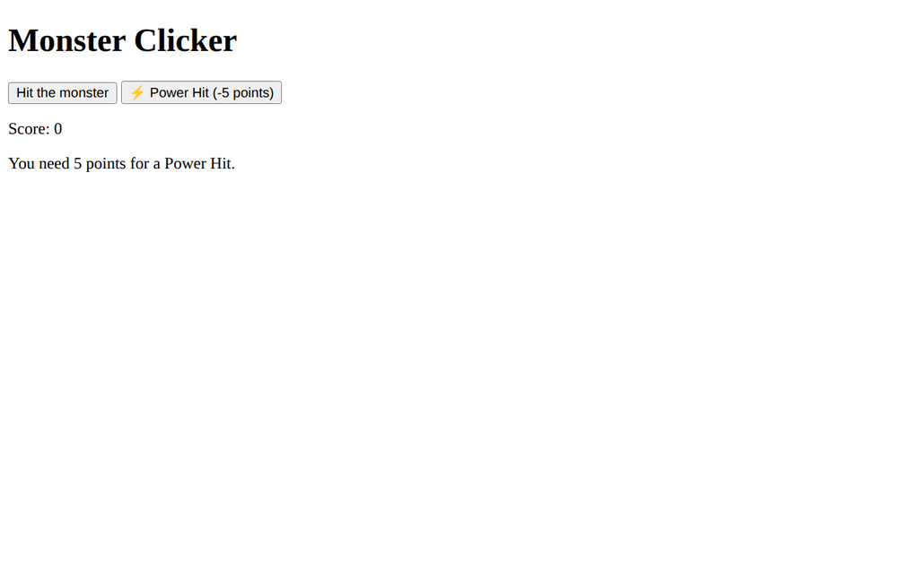

A Power Hit at score zero is refused because five points are required.

[figure not shown]

After five monster clicks, the score reaches five and the level message changes.

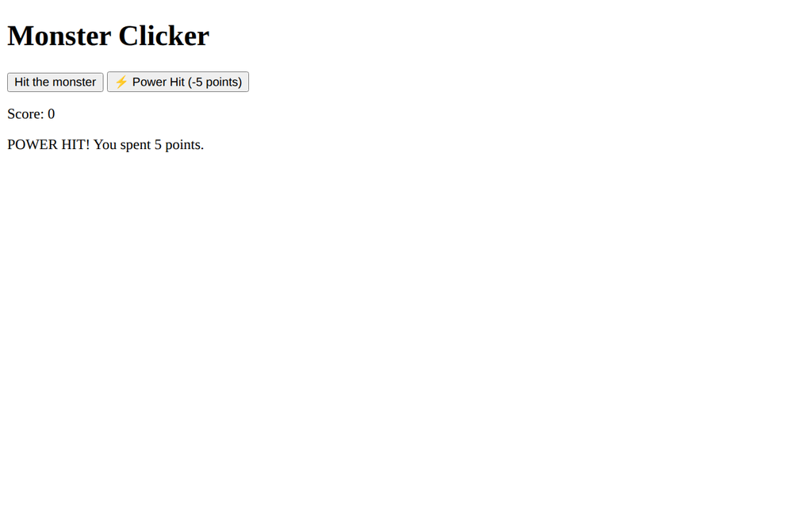

A Power Hit now succeeds and spends the five points.

[figure not shown]

After building the score to ten, the game displays its master-level message.

Open `workspace/chapter5-monster-decisions/index.html` to try the complete example, or save the code above as `index.html`.

### 8.7.1 Trace one game

Suppose the player starts at 0.

1. Click the monster four times. The score becomes 4 and the message says **Keep clicking!**
2. Click one more time. The score becomes 5 and the message changes to **The monster is getting nervous!**
3. Click **Power Hit**. Because `score >= 5` is true, the game spends 5 points and the score returns to 0.
4. Click **Power Hit** again. Now `score >= 5` is false, so the game refuses the move.
5. Build the score to 10. The message changes to **You reached Monster Master level!**

That is branching in action: the same button can lead to different results because the game checks its current state first.

## 8.8 Reading Branches Like a Game Designer

When you see a branch, translate it into a rule written in plain language.

```javascript
if (score >= 10) {
  message.textContent = "You win!";
}
```

Plain-language rule:

> If the player has 10 or more points, show the winning message.

Now go the other direction. Start with a rule:

> If the player has fewer than 3 points, the shield cannot be used.

One possible branch is:

```javascript
if (score < 3) {
  message.textContent = "Not enough points for a shield.";
}
```

This skill becomes very important as games grow. Collision rules, health rules, timers, lives, levels, and winning conditions all depend on decisions.

Advanced Study: Combining Conditions

Sometimes one rule needs more than one condition.

Use `&&` to mean **AND**:

```javascript
if (score >= 5 && score < 10) {
  message.textContent = "Level 2";
}
```

Both conditions must be true.

Use `||` to mean **OR**:

```javascript
if (score === 5 || score === 10) {
  message.textContent = "Milestone reached!";
}
```

At least one condition must be true.

You do not need these operators for the main Monster Clicker yet, but you will see them again in larger games.

## Exercises

Use **Structure → Style → Behavior** as a check before each task. The focus below identifies the stage you are practicing. For reading or prediction tasks, trace or explain the result; you do not need a new page or visual redesign.

### Exercise 1: `true` or `false`?

**Flow focus:** Program game behavior: evaluate the rule using the current score; no scene or style change is needed.

Suppose:

```javascript
let score = 6;
```

Write `true` or `false` for each condition.

1. `score === 6`
2. `score < 5`
3. `score >= 5`
4. `score > 10`
5. `score !== 2`

### Exercise 2: Assignment or comparison?

**Flow focus:** Program game behavior: separate changing game memory from testing a rule.

For each line, decide whether it **stores a value** or **asks a question**.

```javascript
score = 10;
score === 10;
score = score + 1;
score >= 5;
```

### Exercise 3: Predict the branch

**Flow focus:** Program game behavior: trace which rule changes the existing message.

Suppose `score` is 8.

```javascript
if (score < 5) {
  message.textContent = "A";
} else if (score < 10) {
  message.textContent = "B";
} else {
  message.textContent = "C";
}
```

Which letter appears? Explain why.

### Exercise 4: Complete the rule

**Flow focus:** Program game behavior: define the action threshold and check an affordable and an unaffordable case.

Fill in the missing condition so a shield can be used only when the player has at least 3 points.

```javascript
if (________________) {
  message.textContent = "Shield activated!";
} else {
  message.textContent = "Not enough points.";
}
```

### Exercise 5: Add a milestone

**Flow focus:** Program game behavior: reuse the score and message, then test the milestone and its neighboring scores.

Modify the Monster Clicker so the message says **“Halfway there!”** when the score is exactly 5.

## Challenges

### Challenge 1: Add More Monster Levels

**Structure:** Reuse the monster, score, and message areas. **Style:** Make each level message distinguishable while keeping the existing layout. **Behavior:** Define the four ranges and test each boundary and a value between boundaries.

Create at least four score ranges instead of three. For example:

- 0–4: Rookie
- 5–9: Hunter
- 10–19: Monster Master
- 20 or more: Legend

Choose your own messages.

### Challenge 2: Create a Healing Rule

**Structure:** Add a Heal button and reuse the score/message areas. **Style:** Label its cost clearly and make success/refusal feedback readable. **Behavior:** Implement the spending rule and test scores below, at, and above the cost.

Add a button named **Heal** that costs 3 points.

The button should:

- subtract 3 points only when the player has enough points;
- never let the score become negative;
- show a different message when the player cannot afford the action.

### Challenge 3: Design Your Own Rule

**Structure:** Identify which existing parts your new rule uses; add a part only if needed. **Style:** Plan the visible feedback that tells the player the rule occurred. **Behavior:** Write the rule in words, implement its branch, and test both permitted and refused cases.

Invent one new rule for Monster Clicker.

Write the rule first in plain language. Then turn it into an `if`, `if/else`, or `if/else if/else` statement.

Examples of ideas:

- a bonus at a certain score;
- a warning after too many clicks;
- a special move that needs points;
- a new monster level;
- a victory condition.

# 9 Repeat Game Actions with Loops

GAME 09 | Monster Swarm

Loops Arrays Repeated actions

## Overview

Now the monster has called for backup.

Instead of one monster, the game will have several monsters. We *could* write the same JavaScript again and again for every monster, but that becomes tedious very quickly. A **loop** lets JavaScript repeat a block of code for us.

This chapter grows the same Monster Clicker game one more step:

```
Chapter 6: prepare memory for the score
       ↓
Chapter 7: click a monster and update the score
       ↓
Chapter 8: make decisions from the score
       ↓
Chapter 9: repeat actions for many monsters
```

The main idea is simple:

> A branch chooses **which code** should run. A loop chooses **how many times** code should run.

`{mermaid} flowchart LR A[Several monsters] --> B[Array of monster IDs] B --> C[Loop through the array] C --> D[Find each monster] D --> E[Connect the click event]`

By the end of the chapter, one small loop will replace several nearly identical lines of JavaScript.

## Learning Objectives

By the end of this chapter, you will be able to:

- explain why programs use loops;
- identify the three main parts of a `for` loop;
- trace how a loop variable changes during repetition;
- use `.length` so a loop matches the size of an array;
- loop through an array by using an index;
- use a loop to connect click events to several game elements;
- distinguish a loop from a branch;
- recognize how a loop can accidentally run forever.

Structure → Style → Behavior

**Build the scene structure → Style the scene → Program game behavior.**

- **Build the scene structure:** Group the monster buttons and give each a unique ID; list those IDs in the collection.
- **Style the scene:** Use one shared monster class, wrapping, and spacing for the whole group.
- **Behavior:** Use a loop to connect or process the collection; test the first, last, and newly added monster.

Use this plan for the examples and exercises below. Reuse parts that already work; change only what the task needs. After each step, predict one result and check it.

## 9.1 Why Do We Need a Loop?

Imagine that our Monster Clicker now has three monsters:

```html
<button id="slime">Slime</button>
<button id="bat">Bat</button>
<button id="ghost">Ghost</button>
```

We already know how to connect one monster to the `hitMonster()` function:

```javascript
const slime = document.getElementById("slime");
slime.addEventListener("click", hitMonster);
```

For three monsters, we could repeat the same idea:

```javascript
const slime = document.getElementById("slime");
const bat = document.getElementById("bat");
const ghost = document.getElementById("ghost");

slime.addEventListener("click", hitMonster);
bat.addEventListener("click", hitMonster);
ghost.addEventListener("click", hitMonster);
```

This works, but notice the pattern. We are doing almost the same job three times.

```
find a monster → connect its click event
find a monster → connect its click event
find a monster → connect its click event
```

A **loop** is useful when a program needs to repeat a pattern.

Loop Mental Model

A loop says:

**Repeat this block of code while a rule says to keep going.**

A loop does not mean that every game must constantly repeat forever. It can repeat exactly 3 times, 10 times, or once for every item in a list.

## 9.2 Your First `for` Loop

A common JavaScript loop is the **`for` loop**.

Here is a small example:

```javascript
for (let i = 0; i < 3; i++) {
  console.log("A monster appeared!");
}
```

This prints the same message three times.

The first line may look strange at first:

```javascript
for (let i = 0; i < 3; i++) {
```

A `for` loop has three important parts inside the parentheses:

```
for ( START ; KEEP-GOING TEST ; CHANGE )
```

For our example:

```
for ( let i = 0 ; i < 3 ; i++ )
      ─────────   ─────   ───
        start      test   change
```

### 9.2.1 Start: `let i = 0`

```javascript
let i = 0
```

The loop creates a variable named `i` and starts it at `0`.

Programmers often use `i` as a short name for **index**. An index is a position number. You will use indexes with arrays later in this chapter.

### 9.2.2 Keep-going test: `i < 3`

```javascript
i < 3
```

Before each repetition, JavaScript checks this condition.

- If it is `true`, the loop body runs.
- If it is `false`, the loop stops.

### 9.2.3 Change: `i++`

```javascript
i++
```

This adds `1` to `i` after each repetition.

It is a short way to write:

```javascript
i = i + 1;
```

Try It

Change `i < 3` to `i < 5`. Predict how many times the message will appear before you run the code.

## 9.3 Trace a Loop One Step at a Time

Loops become easier when you trace the changing value.

Consider:

```javascript
for (let i = 0; i < 3; i++) {
  console.log(i);
}
```

JavaScript follows these steps:

| Repetition | Value of `i` | Is `i < 3` true? | What happens? |
| --- | --- | --- | --- |
| 1 | 0 | yes | print `0` |
| 2 | 1 | yes | print `1` |
| 3 | 2 | yes | print `2` |
| stop | 3 | no | leave the loop |

So the output is:

```
0
1
2
```

Why does it begin with `0` instead of `1`?

Because JavaScript arrays also begin counting positions at `0`. Starting a loop at `0` will soon become very useful.

Watch Out: `<` Is Important

If the loop starts at `0`, then this repeats **three** times:

```javascript
for (let i = 0; i < 3; i++)
```

The values are `0`, `1`, and `2`.

Using `i <= 3` would also include `3`, so the loop would repeat four times.

## 9.4 Arrays Store Several Values Together

In Chapter 6, you learned that a variable can store different kinds of values. An **array** is a value that can hold several items in order.

Suppose our game has three monsters:

```javascript
const monsterIds = ["slime", "bat", "ghost"];
```

The square brackets `[` and `]` create an array.

The array has three items:

```
Index:       0        1        2
             ↓        ↓        ↓
Value:   "slime"   "bat"   "ghost"
```

We can get one item by putting its index in square brackets:

```javascript
console.log(monsterIds[0]); // slime
console.log(monsterIds[1]); // bat
console.log(monsterIds[2]); // ghost
```

The first item is index `0`, not index `1`.

### 9.4.1 Use `.length` to ask how many items are in an array

```javascript
console.log(monsterIds.length);
```

For our array, `monsterIds.length` is `3`.

This is better than writing the number `3` directly in many places. If we add another monster later, the array’s length changes automatically.

Understand

For an array with 3 items:

- `.length` is `3`;
- valid indexes are `0`, `1`, and `2`;
- the last index is one less than the length.

## 9.5 Loop Through an Array

Now we can combine a loop with an array.

```javascript
const monsterIds = ["slime", "bat", "ghost"];

for (let i = 0; i < monsterIds.length; i++) {
  console.log(monsterIds[i]);
}
```

Trace it:

```
i = 0 → monsterIds[0] → "slime"
i = 1 → monsterIds[1] → "bat"
i = 2 → monsterIds[2] → "ghost"
i = 3 → 3 < 3 is false → stop
```

This pattern is extremely useful:

```javascript
for (let i = 0; i < arrayName.length; i++) {
  // use arrayName[i]
}
```

Read it in plain language:

> Start at the first array position. Keep going while the index is smaller than the number of items. Move to the next position each time.

### 9.5.1 Why use `.length`?

Suppose we add a fourth monster:

```javascript
const monsterIds = ["slime", "bat", "ghost", "dragon"];
```

Our loop still works:

```javascript
for (let i = 0; i < monsterIds.length; i++) {
  console.log(monsterIds[i]);
}
```

We do not need to change `3` into `4`. The loop asks the array for its current length.

## 9.6 Upgrade the Monster Clicker: One Loop, Many Monsters

Now we can solve the real game problem.

Our HTML contains three monster buttons:

```html
<div id="monsters">
  <button id="slime" class="monster">Slime</button>
  <button id="bat" class="monster">Bat</button>
  <button id="ghost" class="monster">Ghost</button>
</div>
```

The JavaScript stores their IDs in an array:

```javascript
const monsterIds = ["slime", "bat", "ghost"];
```

Then a loop visits each ID:

```javascript
for (let i = 0; i < monsterIds.length; i++) {
  const monster = document.getElementById(monsterIds[i]);
  monster.addEventListener("click", hitMonster);
}
```

Look carefully at the line inside the loop:

```javascript
const monster = document.getElementById(monsterIds[i]);
```

Each time the loop repeats, `monsterIds[i]` is different.

```
First time:  monsterIds[0] → "slime"
Second time: monsterIds[1] → "bat"
Third time:  monsterIds[2] → "ghost"
```

So the browser finds each monster and connects the same `hitMonster()` function to it.

`{mermaid} flowchart TD A[monsterIds array] --> B[i = 0: slime] B --> C[i = 1: bat] C --> D[i = 2: ghost] D --> E[All three use hitMonster]`

This is an important programming skill: **when several objects need the same setup, put their information in a collection and loop through it.**

## 9.7 Keep the Score and Branches from Earlier Chapters

The loop is new, but we do not throw away the code from Chapters 7 and 8.

We still keep the score:

```javascript
let score = 0;
const scoreText = document.getElementById("score");
const message = document.getElementById("message");
```

We still update the score when a monster is clicked:

```javascript
function hitMonster() {
  score = score + 1;
  scoreText.textContent = score;

  if (score < 5) {
    message.textContent = "Keep hunting!";
  } else if (score < 10) {
    message.textContent = "Monster Hunter!";
  } else {
    message.textContent = "Monster Master!";
  }
}
```

And the Power Hit rule still uses a branch:

```javascript
function powerHit() {
  if (score >= 5) {
    score = score - 5;
    scoreText.textContent = score;
    message.textContent = "POWER HIT!";
  } else {
    message.textContent = "You need 5 points for a Power Hit.";
  }
}
```

Notice that branches and loops do different jobs:

| Tool | Question it answers | Monster Clicker example |
| --- | --- | --- |
| `if` / `else` | **Should** this code run? | Is the score at least 5? |
| `for` loop | **How many times** should this code run? | Connect every monster button |

A game often needs both.

## 9.8 Build the Complete Monster Swarm Game

Here is the complete version. It continues the ideas from Chapters 6–8, but replaces repeated monster setup with a loop.

COMPLETE EXAMPLE | `index.html`

```html
<!doctype html>
<html lang="en">
<head>
  <meta charset="utf-8">
  <meta name="viewport" content="width=device-width, initial-scale=1">
  <title>Monster Swarm</title>
  <style>
    body {
      font-family: system-ui, sans-serif;
      text-align: center;
      background: #eef7ff;
      color: #17243b;
    }

    main {
      max-width: 650px;
      margin: 40px auto;
      padding: 24px;
      background: white;
      border: 3px solid #17243b;
      border-radius: 20px;
    }

    #monsters {
      display: flex;
      justify-content: center;
      gap: 12px;
      flex-wrap: wrap;
      margin: 24px 0;
    }

    .monster {
      padding: 18px;
      font-size: 1.1rem;
      border: 2px solid #17243b;
      border-radius: 14px;
      background: #e7dcff;
      cursor: pointer;
    }

    #powerHit {
      padding: 12px 18px;
      font-weight: bold;
      cursor: pointer;
    }

    #message {
      min-height: 1.5em;
      font-weight: bold;
    }
  </style>
</head>
<body>
  <main>
    <h1>Monster Swarm</h1>
    <p>Score: <span id="score">0</span></p>

    <div id="monsters">
      <button id="slime" class="monster">Slime</button>
      <button id="bat" class="monster">Bat</button>
      <button id="ghost" class="monster">Ghost</button>
    </div>

    <button id="powerHit">⚡ Power Hit (-5 points)</button>
    <p id="message">Click any monster to begin!</p>
  </main>

  <script>
    let score = 0;

    const scoreText = document.getElementById("score");
    const message = document.getElementById("message");
    const powerHitButton = document.getElementById("powerHit");

    const monsterIds = ["slime", "bat", "ghost"];

    function updateLevelMessage() {
      if (score < 5) {
        message.textContent = "Keep hunting!";
      } else if (score < 10) {
        message.textContent = "Monster Hunter!";
      } else {
        message.textContent = "Monster Master!";
      }
    }

    function hitMonster() {
      score = score + 1;
      scoreText.textContent = score;
      updateLevelMessage();
    }

    function powerHit() {
      if (score >= 5) {
        score = score - 5;
        scoreText.textContent = score;
        message.textContent = "POWER HIT!";
      } else {
        message.textContent = "You need 5 points for a Power Hit.";
      }
    }

    for (let i = 0; i < monsterIds.length; i++) {
      const monster = document.getElementById(monsterIds[i]);
      monster.addEventListener("click", hitMonster);
    }

    powerHitButton.addEventListener("click", powerHit);
  </script>
</body>
</html>
```

[figure not shown]

Structure: HTML only, before CSS or JavaScript.

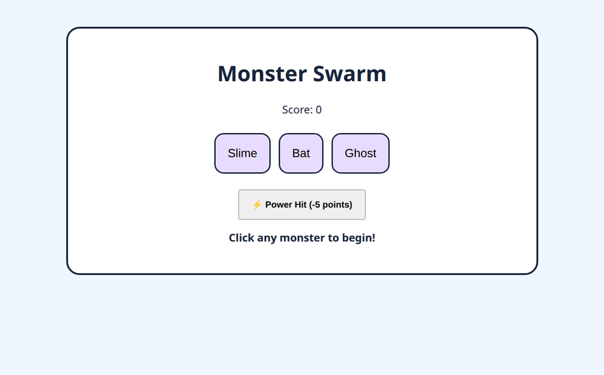

Style: the same HTML with CSS applied; JavaScript is still off.

[figure not shown]

Behavior at the start: the score is zero and the controls are ready.

[figure not shown]

A Power Hit at score zero is refused because five points are required.

[figure not shown]

After five monster clicks, the score reaches five and the level message changes.

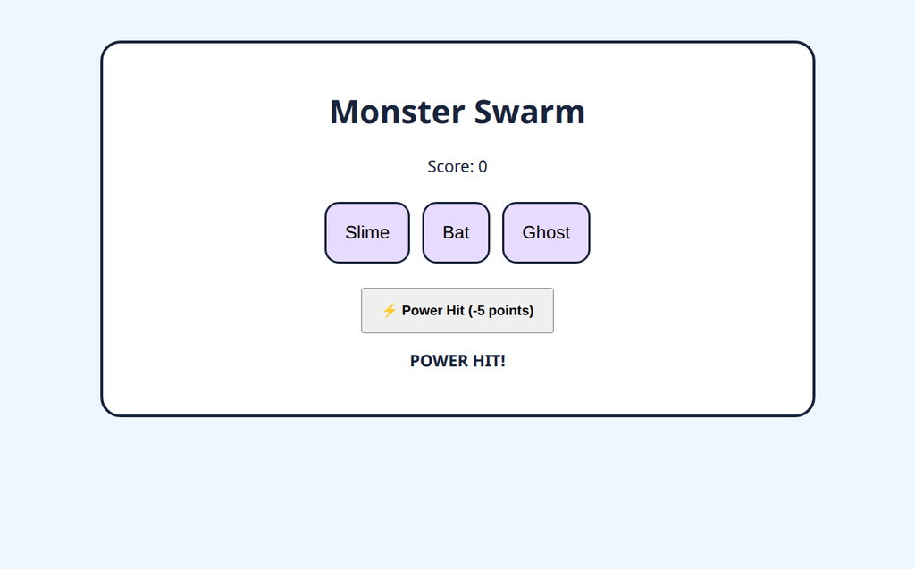

A Power Hit now succeeds and spends the five points.

[figure not shown]

After building the score to ten, the game displays its master-level message.

### 9.8.1 What is new in this version?

The important new code is the array:

```javascript
const monsterIds = ["slime", "bat", "ghost"];
```

and the loop:

```javascript
for (let i = 0; i < monsterIds.length; i++) {
  const monster = document.getElementById(monsterIds[i]);
  monster.addEventListener("click", hitMonster);
}
```

Everything else builds on ideas you already know:

```
DOM element        → Chapter 7
click event        → Chapter 7
score variable     → Chapter 6
if / else branches → Chapter 8
array + loop       → Chapter 9
```

This is how larger programs grow: keep useful code, then add one new idea that solves the next problem.

Try It: Add One More Monster

Add this button to the HTML:

```html
<button id="dragon" class="monster">Dragon</button>
```

Then add only one value to the array:

```javascript
const monsterIds = ["slime", "bat", "ghost", "dragon"];
```

You do **not** need another `addEventListener()` line. The loop takes care of the new monster.

## 9.9 A `while` Loop Repeats While a Condition Is True

A `for` loop is useful when you can count repetitions or move through an array.

JavaScript also has a **`while` loop**:

```javascript
let energy = 3;

while (energy > 0) {
  console.log("Monster attack!");
  energy = energy - 1;
}
```

Read it as:

> While `energy > 0` is true, keep running the block.

The values change like this:

```
energy = 3 → run
energy = 2 → run
energy = 1 → run
energy = 0 → stop
```

A `while` loop is useful when the stopping rule matters more than a fixed number of repetitions.

For now, use a `for` loop as your main tool for stepping through arrays.

Watch Out: Infinite Loops

A loop must eventually reach a stopping condition.

This loop never changes `energy`:

```javascript
let energy = 3;

while (energy > 0) {
  console.log("Attack!");
}
```

Because `energy` stays `3`, the condition stays true forever. This is called an **infinite loop**.

When writing a loop, always ask: **What changes so this loop can stop?**

## 9.10 Another Way to Loop Through an Array

Once you are comfortable with the three-part `for` loop, JavaScript has a shorter form for reading every value in an array:

```javascript
const monsterIds = ["slime", "bat", "ghost"];

for (const monsterId of monsterIds) {
  console.log(monsterId);
}
```

This is called a **`for...of` loop**.

Read it as:

> For each `monsterId` of `monsterIds`, run this code.

We could use it in our game:

```javascript
for (const monsterId of monsterIds) {
  const monster = document.getElementById(monsterId);
  monster.addEventListener("click", hitMonster);
}
```

This version is shorter, but the regular `for` loop is still important because it teaches you how a loop starts, tests a condition, changes, and uses array indexes.

Advanced Study: `for` or `for...of`?

Use a regular `for` loop when you need the index number:

```javascript
for (let i = 0; i < monsterIds.length; i++) {
  console.log(i, monsterIds[i]);
}
```

Use `for...of` when you mainly need each value:

```javascript
for (const monsterId of monsterIds) {
  console.log(monsterId);
}
```

Both are useful. The best choice depends on what information your code needs.

## Exercises

Use **Structure → Style → Behavior** as a check before each task. The focus below identifies the stage you are practicing. For reading or prediction tasks, trace or explain the result; you do not need a new page or visual redesign.

### Exercise 1: Name the Three Parts

**Flow focus:** Program game behavior: identify how repeated operations begin, continue, and stop.

For this loop:

```javascript
for (let i = 0; i < 4; i++) {
  console.log(i);
}
```

Identify:

1. the starting code;
2. the keep-going condition;
3. the code that changes the loop variable.

### Exercise 2: Predict the Output

**Flow focus:** Program game behavior: trace each repeated operation before running it.

What will this code print?

```javascript
for (let i = 0; i < 3; i++) {
  console.log("Hit " + i);
}
```

Write the output before running it.

### Exercise 3: Trace the Array

**Flow focus:** Program game behavior: inspect the collection describing the monsters already in the scene.

Given:

```javascript
const monsters = ["slime", "bat", "ghost", "dragon"];
```

Answer these questions:

1. What is `monsters[0]`?
2. What is `monsters[2]`?
3. What is `monsters.length`?
4. What is the index of `"dragon"`?

### Exercise 4: Complete the Loop

**Flow focus:** Program game behavior: visit each collection item once without changing the page layout.

Fill in the missing parts so every monster name is printed.

```javascript
const monsters = ["slime", "bat", "ghost"];

for (let i = ___; i < monsters.______; i____) {
  console.log(monsters[___]);
}
```

### Exercise 5: Loop or Branch?

**Flow focus:** Program game behavior: choose between deciding a rule and repeating an operation.

Choose **loop** or **branch** for each job.

1. Check whether the player has at least 5 points.
2. Connect the same click event to five monsters.
3. Show one message for beginners and another for high scores.
4. Print every monster name in an array.

### Exercise 6: Find the Bug

**Flow focus:** Program game behavior: check the first and last valid collection positions.

This code tries to print all three monsters:

```javascript
const monsters = ["slime", "bat", "ghost"];

for (let i = 0; i <= monsters.length; i++) {
  console.log(monsters[i]);
}
```

Why does it try to read one position too far? Change one symbol to fix it.

### Exercise 7: Add a Monster

**Flow focus:** Structure → Style → Behavior: add a uniquely named button, reuse the monster class, and include its ID in the loop.

Start with the complete Monster Swarm game. Add a fourth monster button and update the array so the loop connects it automatically.

## Challenges

### Challenge 1: Different Monster Names

**Structure:** Create five uniquely identified monster buttons and list their IDs. **Style:** Reuse the shared monster class and wrapping layout. **Behavior:** Let the existing loop connect them and click the first, last, and newly added monsters.

Create at least five monsters of your own. Put their IDs in the `monsterIds` array and confirm that the same loop connects every monster.

### Challenge 2: Show the Monster List

**Structure:** Keep the monster scene and identify the area that will show the list. **Style:** Keep that list readable within the message area. **Behavior:** Build one list message with a loop and compare it with the collection.

Create an array of display names such as:

```javascript
const monsterNames = ["Slime", "Bat", "Ghost"];
```

Use a loop to build a message that lists all monsters in the game.

Do not write three separate `message.textContent` statements.

### Challenge 3: Count Down a Power Move

**Structure:** Reuse the current scene and identify the Power Hit operation being rehearsed. **Style:** Keep the scene style; console lines are sufficient for this practice task. **Behavior:** Trace the descending counter and check that POWER HIT prints once at the end.

Use a loop to print a countdown in the console:

```
3
2
1
POWER HIT!
```

Decide how your loop should start, when it should stop, and how its counter should change.

### Challenge 4: Create a Monster Wave

**Structure:** Add the new wave with unique monster IDs and a second collection. **Style:** Reuse the monster style so both waves are recognizable. **Behavior:** Connect the new collection with a loop and test every new button.

Add a second array for another wave of monsters. Use the same loop idea to connect each monster in the new wave. Try to avoid copying the event-listener code for every button.

### Challenge 5: Explain Your Design

**Structure:** Identify the button collection and the IDs linking it to the scene. **Style:** Explain how the shared class preserves one style as the collection grows. **Behavior:** Compare the repeated setup code with the loop and describe the change needed for one more monster.

In your own words, explain why this code is easier to expand:

```javascript
for (let i = 0; i < monsterIds.length; i++) {
  const monster = document.getElementById(monsterIds[i]);
  monster.addEventListener("click", hitMonster);
}
```

Compare it with writing a separate `getElementById()` and `addEventListener()` pair for every monster.

# 10 Make Things Change Over Time

GAME 10 | Catch the Star

Timers Coordinates CSS

## Overview

A moving game world changes even when the player is not clicking. Timers let JavaScript run an action again and again.

## Learning Objectives

By the end of this chapter, you can:

- use CSS position values from JavaScript
- use random coordinates
- use `setInterval` and `clearInterval`

Structure → Style → Behavior

**Build the scene structure → Style the scene → Program game behavior.**

- **Build the scene structure:** Keep a star inside a game-area container, with score and any countdown outside it.
- **Style the scene:** Size the arena and star and establish the positioned parent and starting offsets.
- **Behavior:** Move the star with clicks and a timer; check score, speed changes, and how the game stops.

Use this plan for the examples and exercises below. Reuse parts that already work; change only what the task needs. After each step, predict one result and check it.

## 10.1 Move an element

An absolutely positioned element can be moved by changing its left and top CSS properties.

[figure not shown]

Game coordinates: x moves right, y moves down.

**Read the picture:** Start at the top-left corner. Move 25 units right and 35 units down to reach the star. These are example coordinates, not fixed limits for your game; use the size of your own game area.

```javascript
star.style.left = "120px";
star.style.top = "80px";
```

## 10.2 Pick a random position

A helper function makes the star jump to a new place.

```javascript
function moveStar() {
  const x = Math.floor(Math.random() * 280);
  const y = Math.floor(Math.random() * 180);
  star.style.left = x + "px";
  star.style.top = y + "px";
}
```

## 10.3 Repeat an action with a timer

`setInterval` calls a function repeatedly. The number is milliseconds, so 1000 means one second.

```javascript
const timerId = setInterval(moveStar, 1000);

// Later, when the game ends:
clearInterval(timerId);
```

## 10.4 Build the complete game

Put the pieces together. Type the code yourself if you can; typing helps your brain notice punctuation, spelling, and structure.

COMPLETE EXAMPLE

```html
<!doctype html>
<html>
<head>
<style>
  #game { position: relative; width: 340px; height: 240px; border: 2px solid #333; }
  #star { position: absolute; font-size: 36px; cursor: pointer; }
</style>
</head>
<body>
  <h1>Catch the Star</h1>
  <p id="score">Score: 0</p>
  <div id="game"><span id="star">⭐</span></div>
<script>
  let score = 0;
  const star = document.getElementById("star");
  const scoreText = document.getElementById("score");

  function moveStar() {
    const x = Math.floor(Math.random() * 280);
    const y = Math.floor(Math.random() * 180);
    star.style.left = x + "px";
    star.style.top = y + "px";
  }

  star.addEventListener("click", function () {
    score++;
    scoreText.textContent = "Score: " + score;
    moveStar();
  });

  moveStar();
  setInterval(moveStar, 1000);
</script>
</body>
</html>
```

[figure not shown]

Structure: HTML only, before CSS or JavaScript.

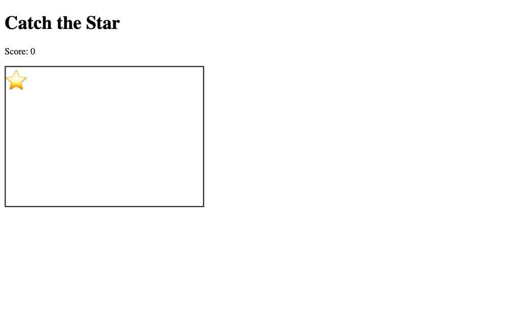

Style: the same HTML with CSS applied; JavaScript is still off.

Open `workspace/chapter7-catch-the-star/index.html` to watch the complete example. The star moves once per second, and a click raises the score and moves it immediately. The screenshot pages use known positions and control one timer callback so their states are reproducible.

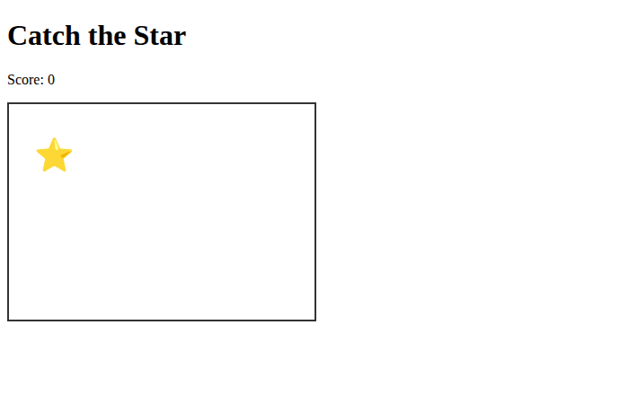

Catch the Star in Chrome at score zero, with the star near the upper left of the game area.

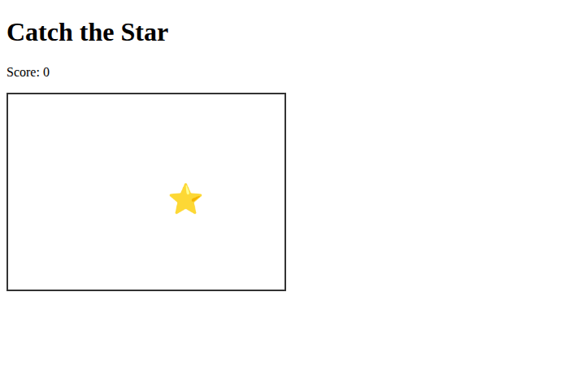

Catch the Star in Chrome after one timer move. The star moves while the score stays zero.

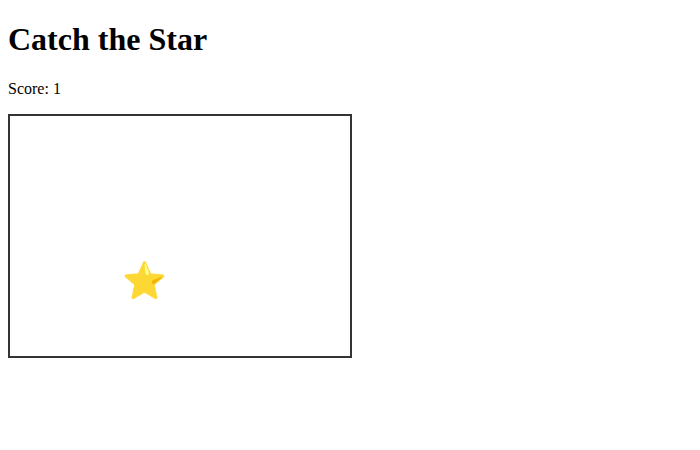

Catch the Star in Chrome after one click. The score is one and the star moves again.

**Read the pictures:** The timer calls `moveStar()` without a player action, changing `left` and `top` while the score remains zero. The click handler also calls `moveStar()`, but first it adds one to `score` and updates the paragraph. The regular page keeps its one-second timer; the demonstration pages control when the callback runs for the screenshots.

Advanced Study | CSS positioning and browser coordinates

OPTIONAL DEEPER DIVE

For positioned HTML elements, left controls horizontal position and top controls vertical position. In browser coordinates, (0,0) is normally the top-left of the containing area, x increases to the right, and y increases downward. Element sizes matter when keeping an object inside the game area.

```javascript
star.style.left = x + 'px';
star.style.top = y + 'px';
```

**Which box do the coordinates belong to?** `#game { position: relative; }` makes the game area the containing block for the absolutely positioned star. Its offsets are measured from that area, not automatically from the entire page.

**Keep the whole object inside.** The largest useful x offset is approximately the game width minus the star width. The same idea applies to height.

**One timer is enough.** Keep the ID returned by `setInterval()` when you need to stop or replace it. Clearing a timer stops scheduled moves, not the separate click listener.

## Level-up challenges

Challenge 1

Make the star move faster after the player reaches 5 points.

1. **Build the scene structure:** Reuse the arena, star, and score display.
2. **Style the scene:** Keep the star visible and inside the arena; faster movement does not require new artwork.
3. **Behavior:** Change the timer schedule at the threshold and check that old timers are cleared.

Challenge 2

Add a 20-second countdown and stop the game when time reaches zero.

1. **Build the scene structure:** Add a countdown display beside the score.
2. **Style the scene:** Make remaining time and the finished state easy to read.
3. **Behavior:** Count down, stop timed movement at zero, and decide whether later clicks can still score.

## Check your development flow

After your exercise or challenge, explain what you built, what you styled, and which game behavior you programmed. If you reused a stage unchanged, say why it already met the task. Record one predicted result and the result you observed, then choose the next small improvement.

# 11 Draw Your Own Game World

GAME 11 | Bouncing Ball

Canvas Animation Velocity

## Overview

Canvas is different from ordinary HTML. Instead of moving page elements, your code redraws the game world frame after frame.

## Learning Objectives

By the end of this chapter, you can:

- create a canvas
- draw shapes with a 2D context
- animate with `requestAnimationFrame`

Structure → Style → Behavior

**Build the scene structure → Style the scene → Program game behavior.**

- **Build the scene structure:** Create the canvas and list each ball with position, radius, and velocity.
- **Style the scene:** Choose the canvas frame and the ball drawing colors and sizes.
- **Behavior:** Update positions, handle edges, and redraw in one animation loop.

Use this plan for the examples and exercises below. Reuse parts that already work; change only what the task needs. After each step, predict one result and check it.

## 11.1 Meet canvas

The canvas element is a rectangular drawing surface. JavaScript asks it for a 2D drawing context.

[figure not shown]

The animation/game loop repeats update and draw work.

**Read the picture:** Each frame is one trip around the cycle. Bouncing Ball has no keyboard input yet, so it begins by updating position. The next chapter adds player input before movement.

```javascript
const canvas = document.getElementById("game");
const ctx = canvas.getContext("2d");
```

## 11.2 Draw a ball

A circle is an arc that goes all the way around.

```javascript
ctx.beginPath();
ctx.arc(x, y, 15, 0, Math.PI * 2);
ctx.fill();
```

## 11.3 Animation is update + draw + repeat

Each frame changes the position, clears the old picture, draws the new picture, and asks the browser for another frame.

```javascript
function loop() {
  x = x + dx;
  y = y + dy;

  ctx.clearRect(0, 0, canvas.width, canvas.height);
  drawBall();

  requestAnimationFrame(loop);
}
```

## 11.4 Bounce at the edges

Reverse a velocity when the ball reaches a wall.

The ball’s position, `(x, y)`, marks its **center**. Its edge is one `radius` away. At the left wall, the ball touches when `x = radius`; at the right wall, it touches when `x = canvas.width - radius`. The same idea gives the top and bottom limits for `y`.

[figure not shown]

Check the ball’s edge, then reverse the velocity that points through the wall.

```javascript
if (x < radius || x > canvas.width - radius) {
  dx = -dx;
}
if (y < radius || y > canvas.height - radius) {
  dy = -dy;
}
```

**Read the picture and code:** `||` means **or**, so either horizontal limit reverses `dx`, and either vertical limit reverses `dy`. Negating a velocity changes its direction while keeping its speed: `3` becomes `-3`, and `-3` becomes `3`. A side-wall bounce keeps `dy` unchanged; a top or bottom bounce keeps `dx` unchanged. At a corner, both `if` statements can run.

The code checks **after moving**. Its strict `<` and `>` comparisons reverse direction on the first frame past a contact limit; equality alone does not trigger a bounce. The diagram shows this small crossing. For example, with a width of `500` and a radius of `15`, the right contact limit is `485`. If a frame moves `x` to `487`, the check reverses `dx` so the next frame moves left.

## 11.5 Build the complete game

Put the pieces together. Type the code yourself if you can; typing helps your brain notice punctuation, spelling, and structure.

COMPLETE EXAMPLE

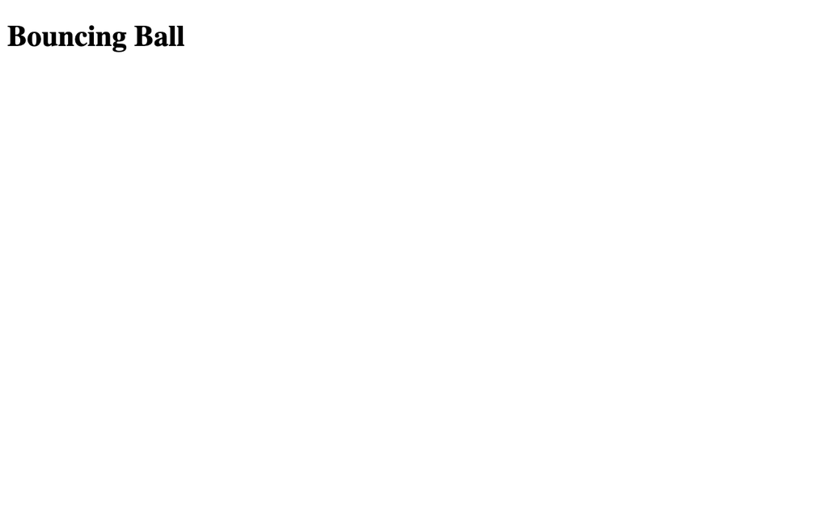

Structure: HTML only, before CSS or JavaScript.

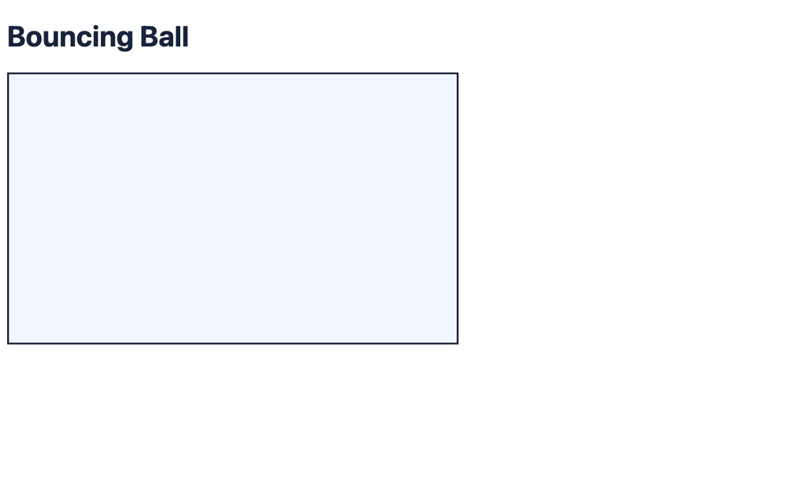

Style: the same HTML with CSS applied; JavaScript is still off.

```html
<!doctype html>
<html lang="en">
<head>
  <meta charset="utf-8">
  <meta name="viewport" content="width=device-width, initial-scale=1">
  <title>Bouncing Ball</title>
  <style>
    body { font-family: system-ui, sans-serif; color: #17243b; }
    canvas { border: 2px solid #17243b; background: #f0f7ff; }
  </style>
</head>
<body>
  <h1>Bouncing Ball</h1>
  <canvas id="game" width="500" height="300"></canvas>
  <script>
    const canvas = document.getElementById("game");
    const ctx = canvas.getContext("2d");
    let x = 100, y = 80;
    let dx = 3, dy = 2;
    const radius = 15;

    function drawBall() {
      ctx.beginPath();
      ctx.arc(x, y, radius, 0, Math.PI * 2);
      ctx.fillStyle = "#6d3df5";
      ctx.fill();
    }

    function loop() {
      x += dx;
      y += dy;
      if (x < radius || x > canvas.width - radius) dx = -dx;
      if (y < radius || y > canvas.height - radius) dy = -dy;
      ctx.clearRect(0, 0, canvas.width, canvas.height);
      drawBall();
      requestAnimationFrame(loop);
    }
    loop();
  </script>
</body>
</html>
```

The empty canvas is expected in these first two stages. JavaScript draws the game objects and runs the behavior shown in the following screenshots.

Open `workspace/chapter6-bouncing-ball/index.html` to watch the complete example. The browser redraws the purple ball on every animation frame. The screenshot pages pause automatic frames and call the same `loop()` function a known number of times.

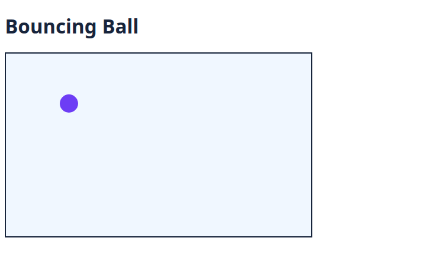

Bouncing Ball in Chrome near its starting position inside the canvas.

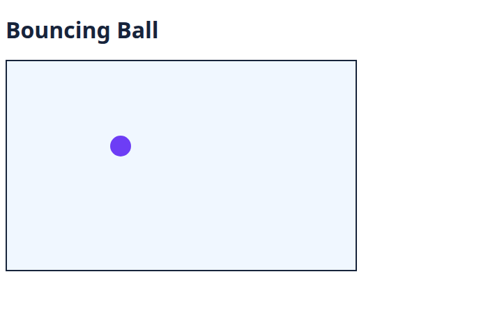

Bouncing Ball in Chrome after twenty more animation frames. The ball has moved right and down.

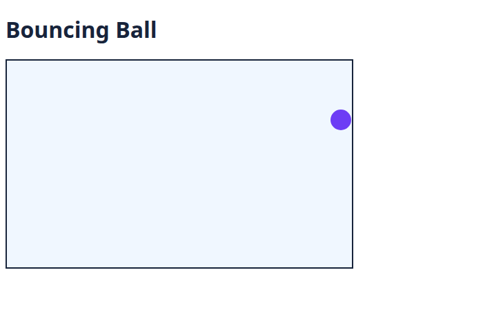

Bouncing Ball in Chrome after reaching the right wall and reversing horizontal direction.

**Read the pictures:** Every `loop()` call changes `x` and `y`, clears the previous drawing, and draws the ball again. At the right wall, `dx` becomes negative, so the next frames move left. The regular page uses `requestAnimationFrame()` to continue automatically.

Advanced Study | requestAnimationFrame and frame time

OPTIONAL DEEPER DIVE

`requestAnimationFrame` asks the browser to run your animation code before the next repaint. Real games should not assume every computer draws the same number of frames per second. Advanced games use the timestamp passed to the callback to calculate delta time so motion depends on elapsed time, not frame count.

```javascript
let previousTime;
function loop(time) {
  const dt = previousTime === undefined
    ? 0
    : (time - previousTime) / 1000;
  previousTime = time;
  update(dt); // Speeds are in pixels per second.
  draw();
  requestAnimationFrame(loop);
}
requestAnimationFrame(loop);
```

**The timestamp is not the time since the last frame.** Subtract the previous timestamp and divide milliseconds by 1000 to get seconds. A speed of 180 pixels per second moves about 3 pixels in a 1/60-second frame.

This is a timing pattern, not a second loop to add beside the existing one. Supply your own `update(dt)` and `draw()` functions. Start the pattern with `requestAnimationFrame(loop)`. A more robust game should also handle a long pause, for example by resetting its previous timestamp when resuming.

Further reading: [MDN: requestAnimationFrame](https://developer.mozilla.org/en-US/docs/Web/API/Window/requestAnimationFrame).

## Level-up challenges

Challenge 1

Change the ball speed. What values feel playable?

1. **Build the scene structure:** Reuse the ball and canvas.
2. **Style the scene:** Keep the ball size/color and frame unchanged so the comparison is fair.
3. **Behavior:** Change velocity, observe several edge bounces, and compare playable speeds.

Challenge 2

Add a second ball with its own position and velocity.

1. **Build the scene structure:** Describe a second ball with independent position and velocity.
2. **Style the scene:** Draw it in a distinguishable color within the same canvas.
3. **Behavior:** Update and bounce both balls in the existing loop.

## Check your development flow

After your exercise or challenge, explain what you built, what you styled, and which game behavior you programmed. If you reused a stage unchanged, say why it already met the task. Record one predicted result and the result you observed, then choose the next small improvement.

# 12 Control a Real-Time Game

GAME 12 | Pong

Keyboard input State Collision

## Overview

In a real-time game, a key press should change what happens during the next frames. Instead of moving once per key event, we remember which keys are held down.

## Learning Objectives

By the end of this chapter, you can:

- track pressed keys
- move a paddle every frame
- detect simple rectangle/ball collisions

Structure → Style → Behavior

**Build the scene structure → Style the scene → Program game behavior.**

- **Build the scene structure:** Place the canvas, paddles, ball, instructions, and score display.
- **Style the scene:** Draw distinguishable paddles and ball and make the controls and score legible.
- **Behavior:** Read held keys, update movement, resolve paddle hits, and test scoring and misses.

Use this plan for the examples and exercises below. Reuse parts that already work; change only what the task needs. After each step, predict one result and check it.

How to use the code pieces

The short snippets below explain individual rules. The complete browser example later in this chapter combines them into a playable page.

## 12.1 Remember key state

`keydown` sets a state to `true`. `keyup` changes it back to `false`.

[figure not shown]

Keyboard events update state; the game loop uses that state.

**Read the picture:** An event changes a remembered value. The loop can then read that value on many frames. The picture uses a right-arrow flag; Pong uses the same idea for the up and down arrows.

```javascript
const keys = {};

window.addEventListener("keydown", e => {
  keys[e.key] = true;
});
window.addEventListener("keyup", e => {
  keys[e.key] = false;
});
```

## 12.2 Move during the update

The game loop checks the state every frame.

```javascript
if (keys["ArrowUp"]) paddleY -= 5;
if (keys["ArrowDown"]) paddleY += 5;
```

## 12.3 Keep the paddle on the screen

`Math.max` and `Math.min` can clamp a value inside a range.

```javascript
paddleY = Math.max(0, paddleY);
paddleY = Math.min(canvas.height - paddleH, paddleY);
```

## 12.4 Paddle collision idea

For a first Pong game, place a vertical paddle on the right. Here, paddleX and paddleY are its top-left coordinates, paddleW and paddleH are its size, and positive dx means the ball is moving right. Test the ball bounding box against the paddle before reversing direction.

[figure not shown]

A paddle bounce needs overlap on both axes and a ball moving toward the paddle.

```javascript
const overlapsPaddle = (
  ballX + radius >= paddleX &&
  ballX - radius <= paddleX + paddleW &&
  ballY + radius >= paddleY &&
  ballY - radius <= paddleY + paddleH
);
if (dx > 0 && overlapsPaddle) {
  ballX = paddleX - radius;
  dx = -Math.abs(dx);
}
```

**Read the picture and code:** The first two comparisons test horizontal overlap; the last two test vertical overlap. `&&` means **and**, so all four must be true. For example, a ball above the paddle fails the vertical test even if it has reached the paddle’s x position. The `>=` and `<=` comparisons include touching edges. This beginner version uses the square around the circle, so it can also count a near-corner overlap where the drawn circle does not quite touch.

The response has two jobs. First, `ballX = paddleX - radius` places the ball just outside the paddle, with its right edge at `paddleX`. Then `dx = -Math.abs(dx)` sends it left, keeping the same horizontal speed. `dy` stays unchanged. The `dx > 0` guard allows a hit only while moving right, so a ball already moving away does not bounce again or add another hit.

**Wall bounces and a miss:** The complete example below also checks the left, top, and bottom edges after moving the ball. Follow each rule in the next diagram, then find its matching `if` statement inside `update()`.

[figure not shown]

Pong bounces at three walls and resets after a miss on the right.

**Read the wall rules:** At the left wall, `Math.abs(dx)` makes horizontal velocity positive, so the ball travels right. At the top or bottom, `dy = -dy` reverses vertical direction. As in Chapter 11, these strict wall comparisons trigger just past the contact limit. A right-side miss uses a different limit: `ballX > canvas.width + radius`. Only then has the whole ball left the canvas. The game resets its center to `(100, canvas.height / 2)` and makes `dx` positive; it keeps the current `dy` and hit count. The paddle’s overlap check runs before this miss check.

## Play Pong in your browser

Save this page as `index.html`, or open `workspace/chapter9-pong/index.html`. Hold the up or down arrow to move the right paddle. The game loop reads the remembered key state every frame and checks whether the ball overlaps the paddle.

COMPLETE EXAMPLE | `index.html`

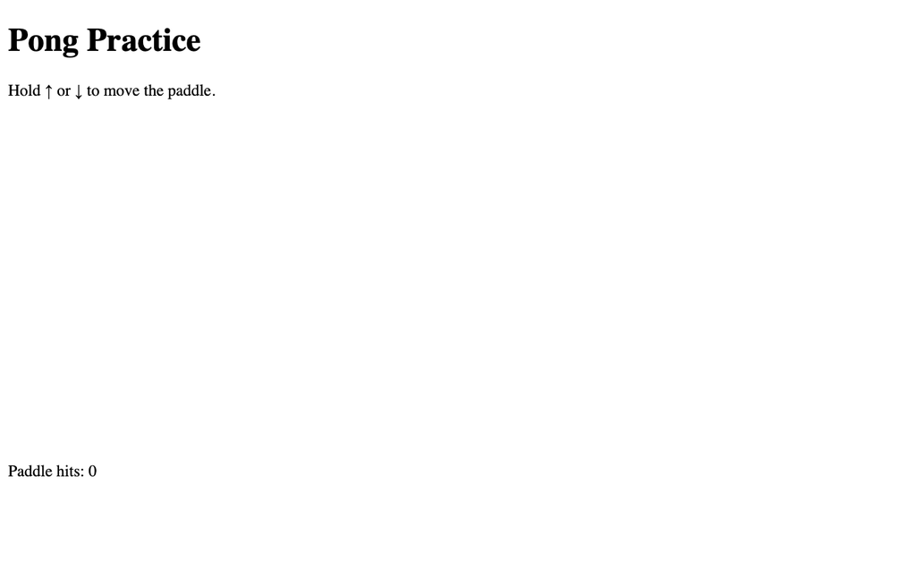

Structure: HTML only, before CSS or JavaScript.

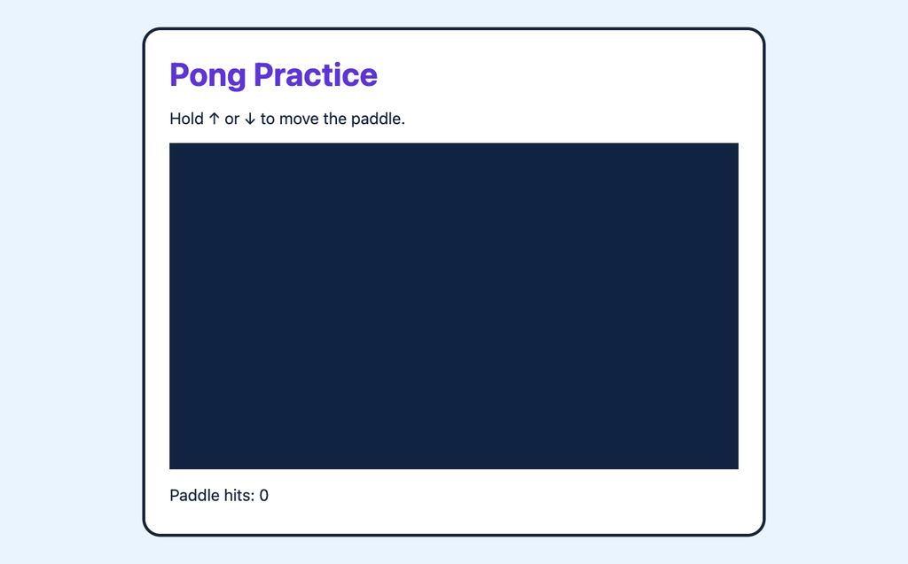

Style: the same HTML with CSS applied; JavaScript is still off.

```html
<!doctype html>
<html lang="en">
<head>
  <meta charset="utf-8">
  <meta name="viewport" content="width=device-width, initial-scale=1">
  <title>Pong Practice</title>
  <style>
    body { margin: 0; min-height: 100vh; display: grid; place-items: center; background: #eaf4ff; font-family: system-ui, sans-serif; color: #17243b; }
    main { padding: 24px; border: 3px solid #17243b; border-radius: 18px; background: white; }
    h1 { margin: 0 0 8px; color: #5d35d5; }
    canvas { display: block; border: 2px solid #17243b; background: #102342; }
    #status { min-height: 1.5em; margin-bottom: 0; }
  </style>
</head>
<body>
  <main>
    <h1>Pong Practice</h1>
    <p>Hold ↑ or ↓ to move the paddle.</p>
    <canvas id="game" width="560" height="320"></canvas>
    <p id="status">Paddle hits: 0</p>
  </main>
  <script>
    const canvas = document.getElementById("game");
    const ctx = canvas.getContext("2d");
    const status = document.getElementById("status");
    const keys = {};
    window.addEventListener("keydown", e => {
      if (e.key === "ArrowUp" || e.key === "ArrowDown") e.preventDefault();
      keys[e.key] = true;
    });
    window.addEventListener("keyup", e => { keys[e.key] = false; });
    window.addEventListener("blur", () => {
      keys.ArrowUp = false;
      keys.ArrowDown = false;
    });

    const paddleX = 530, paddleW = 12, paddleH = 70;
    let paddleY = 125;
    let ballX = 100, ballY = 160;
    let dx = 3, dy = 2;
    const radius = 10;
    let hits = 0;

    function update() {
      if (keys["ArrowUp"]) paddleY -= 5;
      if (keys["ArrowDown"]) paddleY += 5;
      paddleY = Math.max(0, paddleY);
      paddleY = Math.min(canvas.height - paddleH, paddleY);

      ballX += dx;
      ballY += dy;
      if (ballX < radius) dx = Math.abs(dx);
      if (ballY < radius || ballY > canvas.height - radius) dy = -dy;

      const overlapsPaddle = (
        ballX + radius >= paddleX &&
        ballX - radius <= paddleX + paddleW &&
        ballY + radius >= paddleY &&
        ballY - radius <= paddleY + paddleH
      );
      if (dx > 0 && overlapsPaddle) {
        ballX = paddleX - radius;
        dx = -Math.abs(dx);
        hits++;
        status.textContent = "Paddle hits: " + hits;
      }
      if (ballX > canvas.width + radius) {
        ballX = 100;
        ballY = canvas.height / 2;
        dx = Math.abs(dx);
        status.textContent = "Missed! Paddle hits: " + hits;
      }
    }

    function draw() {
      ctx.clearRect(0, 0, canvas.width, canvas.height);
      ctx.fillStyle = "#102342";
      ctx.fillRect(0, 0, canvas.width, canvas.height);
      ctx.fillStyle = "#86d8ff";
      ctx.fillRect(paddleX, paddleY, paddleW, paddleH);
      ctx.beginPath();
      ctx.arc(ballX, ballY, radius, 0, Math.PI * 2);
      ctx.fillStyle = "#ffe48a";
      ctx.fill();
    }

    function loop() {
      update();
      draw();
      requestAnimationFrame(loop);
    }
    draw();
    requestAnimationFrame(loop);
  </script>
</body>
</html>
```

The empty canvas is expected in these first two stages. JavaScript draws the game objects and runs the behavior shown in the following screenshots.

The demonstration pages pause automatic animation, then make a known number of updates or one paddle collision. The playable page keeps animating normally.

[figure not shown]

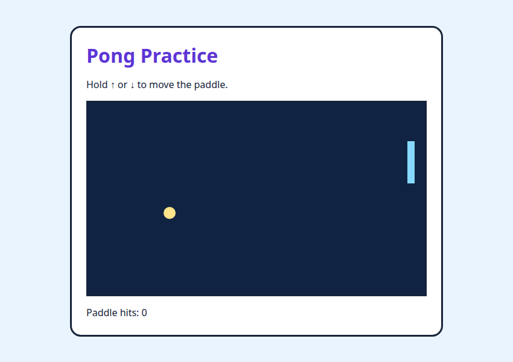

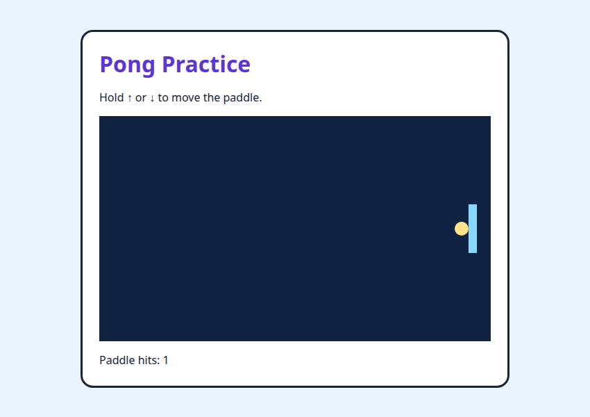

**Read the pictures:** A held key keeps `keys["ArrowUp"]` true, so the paddle moves through several updates. When the ball reaches the paddle, the overlap test becomes true and `dx` changes sign. The hit count confirms that the collision response ran once.

Advanced Study | Input state versus input events

OPTIONAL DEEPER DIVE

An event tells you that something happened once. A state variable remembers whether a key is currently held down. Real-time games usually update state in `keydown`/`keyup` handlers and let the game loop decide how far to move the player each frame.

```javascript
let rightPressed = false;
window.addEventListener("keydown", e => {
  if (e.key === "ArrowRight") rightPressed = true;
});
window.addEventListener("keyup", e => {
  if (e.key === "ArrowRight") rightPressed = false;
});
```

**Events are messages; state is memory.** Holding a key may produce repeated `keydown` events, but we do not use those repeats as a movement clock. A true flag means the loop should keep moving the paddle.

**Focus matters.** A finished game should clear remembered keys when it loses focus, because a key-up event may not arrive where expected. Prevent arrow-key scrolling only while the player is controlling the game, rather than blocking page navigation everywhere.

## Level-up challenges

Challenge 1

Add a second paddle controlled by W and S.

1. **Build the scene structure:** Add a second paddle and identify its starting position.
2. **Style the scene:** Distinguish the paddles and add clear W/S instructions.
3. **Behavior:** Track W/S input, constrain movement, and test ball contact with both paddles.

Challenge 2

Add a score when the ball passes a paddle.

1. **Build the scene structure:** Identify the score display and which side earns each point.
2. **Style the scene:** Keep the score and any reset feedback readable.
3. **Behavior:** Award one point on a miss, reset the ball, and check that the same miss is not counted again.

Challenge 3

Make the ball slightly faster after each paddle hit.

1. **Build the scene structure:** Reuse the ball, paddles, and collision test.
2. **Style the scene:** Keep the current drawing while comparing speeds.
3. **Behavior:** Increase speed once per hit and test successive hits and misses.

## Check your development flow

After your exercise or challenge, explain what you built, what you styled, and which game behavior you programmed. If you reused a stage unchanged, say why it already met the task. Record one predicted result and the result you observed, then choose the next small improvement.

# 13 Manage Many Game Objects

GAME 13 | Breakout

Objects Arrays Loops

## Overview

Breakout has many bricks. We do not want 30 separate variables. Arrays let one variable hold a whole collection of game objects.

## Learning Objectives

By the end of this chapter, you can:

- store many objects in an array
- use loops to update and draw objects
- remove or mark hit bricks
- understand basic collision tests

Structure → Style → Behavior

**Build the scene structure → Style the scene → Program game behavior.**

- **Build the scene structure:** Describe the paddle, ball, and brick collection, including positions and active flags.
- **Style the scene:** Draw the bricks and any remaining-hit feedback so their state is visible.
- **Behavior:** Process the collection, handle each hit once, and check score and victory rules.

Use this plan for the examples and exercises below. Reuse parts that already work; change only what the task needs. After each step, predict one result and check it.

How to use the code pieces

The short snippets below explain individual rules. The complete browser example later in this chapter combines them into a playable page.

## 13.1 Store bricks as objects

Each brick can be an object with position, size, and whether it is still active.

[figure not shown]

Collision detection asks whether game objects overlap.

**Read the picture:** A collision is not just being close. The shapes overlap horizontally **and** vertically. The picture uses rectangles; the beginner ball test uses a square bounding box around the ball.

```javascript
const bricks = [
  { x: 20, y: 20, w: 60, h: 20, alive: true },
  { x: 90, y: 20, w: 60, h: 20, alive: true },
  { x: 160, y: 20, w: 60, h: 20, alive: true }
];
```

## 13.2 Loop through the array

`for...of` gives us each brick one at a time.

```javascript
for (const brick of bricks) {
  if (brick.alive) {
    ctx.fillRect(brick.x, brick.y, brick.w, brick.h);
  }
}
```

## 13.3 A simple collision test

A ball hits a brick when its position overlaps the brick rectangle. For a beginner version, we can use the ball center plus its radius.

```javascript
function hitsBrick(ballX, ballY, r, brick) {
  return (
    ballX + r > brick.x &&
    ballX - r < brick.x + brick.w &&
    ballY + r > brick.y &&
    ballY - r < brick.y + brick.h
  );
}
```

## 13.4 Change the world after a hit

When a collision happens, mark the brick as no longer alive and reverse the vertical direction of the ball.

```javascript
if (brick.alive && hitsBrick(x, y, radius, brick)) {
  brick.alive = false;
  dy = -dy;
  score++;
}
```

## Play Breakout in your browser

Save this page as `index.html`, or open `workspace/chapter10-breakout/index.html`. Each brick is an object in the `bricks` array. The loop draws only active bricks and tests the ball against them.

COMPLETE EXAMPLE | `index.html`

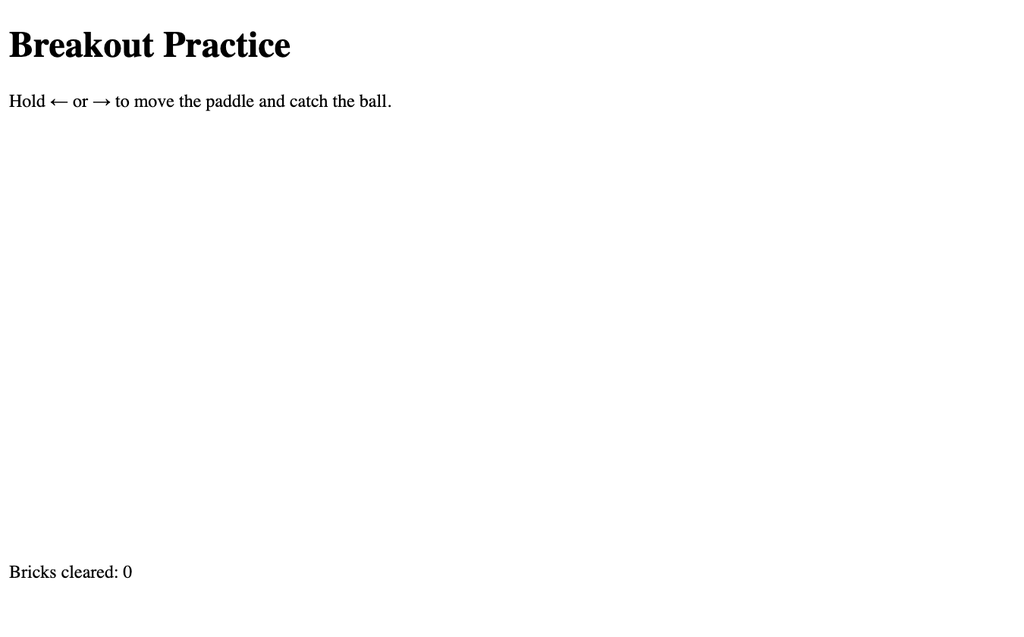

Structure: HTML only, before CSS or JavaScript.

[figure not shown]

Style: the same HTML with CSS applied; JavaScript is still off.

```html
<!doctype html>
<html lang="en">
<head>
  <meta charset="utf-8">
  <meta name="viewport" content="width=device-width, initial-scale=1">
  <title>Breakout Practice</title>
  <style>
    body { margin: 0; min-height: 100vh; display: grid; place-items: center; background: #fff3e8; font-family: system-ui, sans-serif; color: #17243b; }
    main { padding: 24px; border: 3px solid #17243b; border-radius: 18px; background: white; }
    h1 { margin: 0 0 8px; color: #c04a5a; }
    canvas { display: block; border: 2px solid #17243b; background: #17243b; }
    #status { min-height: 1.5em; margin-bottom: 0; }
  </style>
</head>
<body>
  <main>
    <h1>Breakout Practice</h1>
    <p>Hold ← or → to move the paddle and catch the ball.</p>
    <canvas id="game" width="560" height="360"></canvas>
    <p id="status">Bricks cleared: 0</p>
  </main>
  <script>
    const canvas = document.getElementById("game");
    const ctx = canvas.getContext("2d");
    const status = document.getElementById("status");
    const keys = {};
    window.addEventListener("keydown", e => {
      if (e.key === "ArrowLeft" || e.key === "ArrowRight") e.preventDefault();
      keys[e.key] = true;
    });
    window.addEventListener("keyup", e => { keys[e.key] = false; });
    window.addEventListener("blur", () => {
      keys.ArrowLeft = false;
      keys.ArrowRight = false;
    });

    const bricks = [
      { x: 45, y: 40, w: 100, h: 22, alive: true },
      { x: 165, y: 40, w: 100, h: 22, alive: true },
      { x: 285, y: 40, w: 100, h: 22, alive: true },
      { x: 405, y: 40, w: 100, h: 22, alive: true },
      { x: 45, y: 76, w: 100, h: 22, alive: true },
      { x: 165, y: 76, w: 100, h: 22, alive: true },
      { x: 285, y: 76, w: 100, h: 22, alive: true },
      { x: 405, y: 76, w: 100, h: 22, alive: true }
    ];
    let paddleX = 230;
    const paddleY = 330, paddleW = 100, paddleH = 12;
    let x = 280, y = 250, dx = 3, dy = -3;
    const radius = 10;
    let score = 0;

    function hitsBrick(ballX, ballY, r, brick) {
      return (
        ballX + r > brick.x &&
        ballX - r < brick.x + brick.w &&
        ballY + r > brick.y &&
        ballY - r < brick.y + brick.h
      );
    }

    function update() {
      if (keys.ArrowLeft) paddleX -= 6;
      if (keys.ArrowRight) paddleX += 6;
      paddleX = Math.max(0, Math.min(canvas.width - paddleW, paddleX));
      x += dx;
      y += dy;
      if (x < radius || x > canvas.width - radius) dx = -dx;
      if (y < radius) dy = Math.abs(dy);
      if (dy > 0 && y + radius >= paddleY && y - radius <= paddleY + paddleH &&
          x + radius >= paddleX && x - radius <= paddleX + paddleW) {
        y = paddleY - radius;
        dy = -Math.abs(dy);
      }
      for (const brick of bricks) {
        if (brick.alive && hitsBrick(x, y, radius, brick)) {
          brick.alive = false;
          dy = -dy;
          score++;
          status.textContent = "Bricks cleared: " + score;
          break;
        }
      }
      if (y > canvas.height + radius) {
        x = canvas.width / 2;
        y = 250;
        dy = -3;
        status.textContent = "Try again! Bricks cleared: " + score;
      }
    }

    function draw() {
      ctx.clearRect(0, 0, canvas.width, canvas.height);
      ctx.fillStyle = "#17243b";
      ctx.fillRect(0, 0, canvas.width, canvas.height);
      for (const brick of bricks) {
        if (brick.alive) {
          ctx.fillStyle = brick.y === 40 ? "#f899b5" : "#ffe48a";
          ctx.fillRect(brick.x, brick.y, brick.w, brick.h);
        }
      }
      ctx.fillStyle = "#8ce3ff";
      ctx.fillRect(paddleX, paddleY, paddleW, paddleH);
      ctx.beginPath();
      ctx.arc(x, y, radius, 0, Math.PI * 2);
      ctx.fillStyle = "white";
      ctx.fill();
    }

    function loop() {
      update();
      draw();
      requestAnimationFrame(loop);
    }
    draw();
    requestAnimationFrame(loop);
  </script>
</body>
</html>
```

The empty canvas is expected in these first two stages. JavaScript draws the game objects and runs the behavior shown in the following screenshots.

The demonstration pages pause automatic animation and place the ball for one or three known brick collisions. The playable page keeps animating normally.

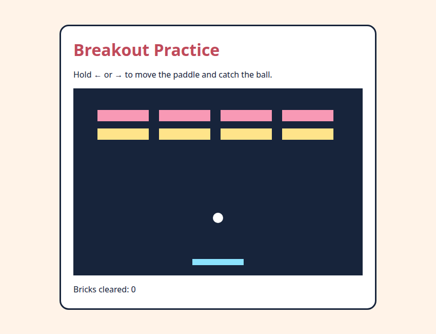

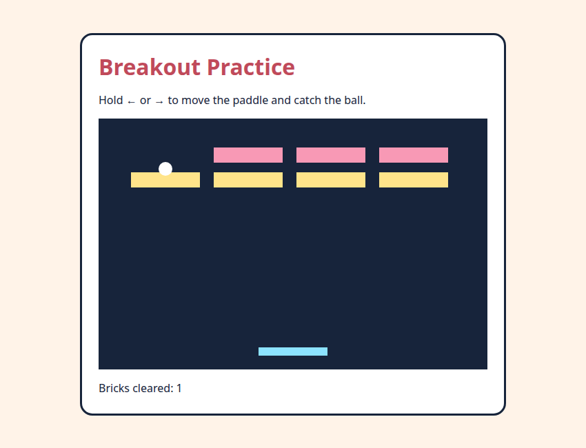

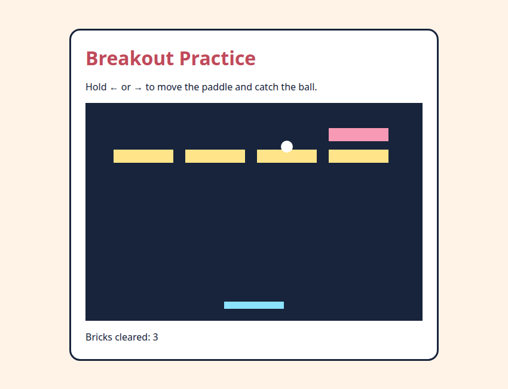

**Read the pictures:** `hitsBrick()` finds an overlap, then the code sets that brick’s `alive` property to false. The next draw skips it, so a gap appears in the row. The score rises from zero to one, then three. The brick object stays in the array even though it is no longer drawn or hit.

Advanced Study | Objects, arrays, and collision logic

OPTIONAL DEEPER DIVE

An object groups properties that belong to one game object. An array stores many objects in order. A common rectangle collision test checks whether one rectangle is not completely left, right, above, or below the other. Larger games often separate `update()`, `draw()`, and collision functions.

```javascript
const brick = { x: 40, y: 20, w: 60, h: 20, alive: true };
bricks.push(brick);
```

**Each object is one brick; the array is the collection.** `brick.alive = false` changes a property on that brick. A `for...of` loop can visit the collection when checking collisions and when drawing.

**Know the approximation.** `hitsBrick` checks the square around the ball against the brick. At a corner, those squares can overlap before the circle itself touches. A fast ball can also jump past a thin brick between frames.

**One hit, one response.** Avoid reversing the ball repeatedly for several bricks in one update. A simple first approach is to stop checking after the first detected hit.

## Level-up challenges

Challenge 1

Create the brick array with nested loops instead of typing each brick.

1. **Build the scene structure:** Describe brick rows and columns and the same starting positions.
2. **Style the scene:** Keep brick sizes, spacing, and colors consistent.
3. **Behavior:** Generate the collection with nested loops and compare its count and layout with the original.

Challenge 2

Give some bricks two hit points.

1. **Build the scene structure:** Add remaining hit points to the chosen bricks.
2. **Style the scene:** Show remaining strength with distinct colors or labels.
3. **Behavior:** Reduce strength once per collision and remove/score a brick only at zero.

Challenge 3

Add a win condition when every brick is gone.

1. **Build the scene structure:** Reuse the brick collection and add a victory message only if needed.
2. **Style the scene:** Make the cleared board and victory feedback understandable.
3. **Behavior:** Detect when no active bricks remain and decide how updates stop or transition.

## Check your development flow

After your exercise or challenge, explain what you built, what you styled, and which game behavior you programmed. If you reused a stage unchanged, say why it already met the task. Record one predicted result and the result you observed, then choose the next small improvement.

# 14 Build a World on a Grid

GAME 14 | Snake

Grid cells Arrays Game state

## Overview

Snake becomes easier when the world is a grid. Instead of moving by tiny pixels, the snake moves one cell at a time.

## Learning Objectives

By the end of this chapter, you can:

- represent positions as grid cells
- store the snake as an array
- update the world one step at a time
- detect self and wall collisions

Structure → Style → Behavior

**Build the scene structure → Style the scene → Program game behavior.**

- **Build the scene structure:** Describe the grid, snake cells, food, obstacles, and start/restart controls.
- **Style the scene:** Make food, snake, walls, and game-state messages visually distinct.
- **Behavior:** Update grid movement, growth, collisions, speed changes, and resets.

Use this plan for the examples and exercises below. Reuse parts that already work; change only what the task needs. After each step, predict one result and check it.

How to use the code pieces

The short snippets below explain individual rules. The complete browser example later in this chapter combines them into a playable page.

## 14.1 A snake is a list of body cells

The first item can be the head. Each cell stores x and y coordinates.

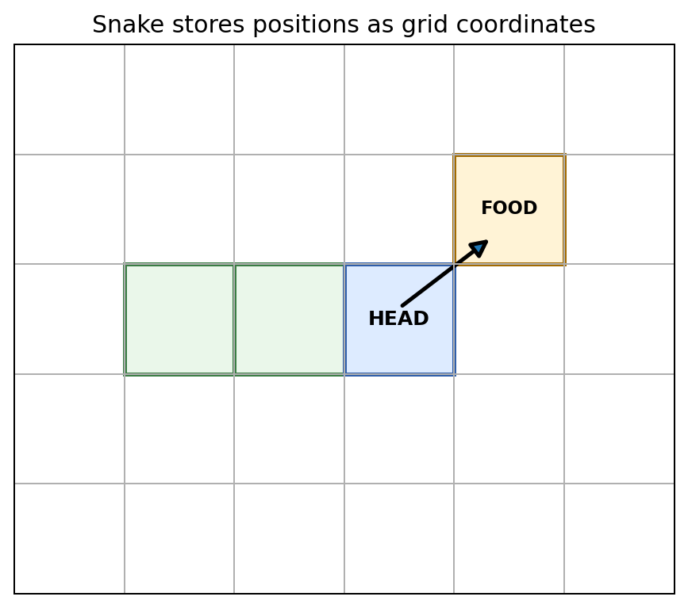

A grid game stores positions as x/y cells.

**Read the picture:** Each square is one cell, not one screen pixel. The head is the first item in the body array. The arrow points toward food; it does not allow a diagonal move. Move one horizontal or vertical cell per step.

```javascript
let snake = [
  { x: 5, y: 5 },
  { x: 4, y: 5 },
  { x: 3, y: 5 }
];
```

## 14.2 Move by creating a new head

We calculate a new head from the old head and the current direction. Then `unshift` adds it to the front. `pop` removes the last tail cell.

```javascript
const head = snake[0];
const newHead = { x: head.x + dx, y: head.y + dy };
snake.unshift(newHead);
snake.pop();
```

## 14.3 Grow when food is eaten

If the head lands on food, do not remove the tail that step. The snake becomes one cell longer.

```javascript
if (newHead.x === food.x && newHead.y === food.y) {
  score++;
  placeFood();
} else {
  snake.pop();
}
```

## 14.4 Prevent instant reverse direction

If the snake is moving right, switching directly to left would make the head collide with the body. Check the old direction before accepting the new one.

```javascript
if (e.key === "ArrowLeft" && dx !== 1) {
  dx = -1;
  dy = 0;
}
```

## Play Snake in your browser

Save this page as `index.html`, or open `workspace/chapter9-snake/index.html`. The snake is an array of grid cells. Each step adds a new head; eating food keeps the tail, and an ordinary step removes it.

COMPLETE EXAMPLE | `index.html`

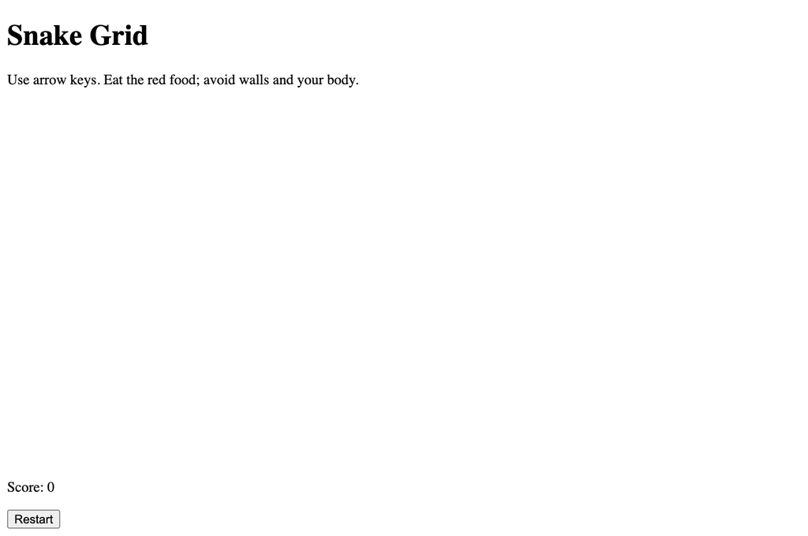

Structure: HTML only, before CSS or JavaScript.

[figure not shown]

Style: the same HTML with CSS applied; JavaScript is still off.

```html
<!doctype html>
<html lang="en">
<head>
  <meta charset="utf-8">
  <meta name="viewport" content="width=device-width, initial-scale=1">
  <title>Snake Grid</title>
  <style>
    body { margin: 0; min-height: 100vh; display: grid; place-items: center; background: #e8f8ef; color: #193b2d; font-family: system-ui, sans-serif; }
    main { padding: 24px; border: 3px solid #193b2d; border-radius: 18px; background: white; }
    h1 { margin: 0 0 8px; color: #24875d; }
    canvas { display: block; border: 2px solid #193b2d; background: #f4fff8; }
    button { margin-top: 10px; padding: 8px 14px; font: inherit; }
  </style>
</head>
<body>
  <main>
    <h1>Snake Grid</h1>
    <p>Use arrow keys. Eat the red food; avoid walls and your body.</p>
    <canvas id="game" width="400" height="400"></canvas>
    <p id="status">Score: 0</p>
    <button id="restart" type="button">Restart</button>
  </main>
  <script>
    const canvas = document.getElementById("game");
    const ctx = canvas.getContext("2d");
    const status = document.getElementById("status");
    const cell = 20, count = canvas.width / cell;
    let snake, food, dx, dy, score, gameOver, turned;

    function reset() {
      snake = [{ x: 5, y: 5 }, { x: 4, y: 5 }, { x: 3, y: 5 }];
      food = { x: 8, y: 5 };
      dx = 1; dy = 0; score = 0; gameOver = false; turned = false;
      status.textContent = "Score: 0";
      draw();
    }

    function placeFood() {
      do {
        food = { x: Math.floor(Math.random() * count), y: Math.floor(Math.random() * count) };
      } while (snake.some(part => part.x === food.x && part.y === food.y));
    }

    window.addEventListener("keydown", e => {
      const turns = { ArrowUp: [0, -1], ArrowDown: [0, 1], ArrowLeft: [-1, 0], ArrowRight: [1, 0] };
      const next = turns[e.key];
      if (!next) return;
      e.preventDefault();
      if (!turned && (next[0] !== -dx || next[1] !== -dy)) {
        [dx, dy] = next;
        turned = true;
      }
    });
    document.getElementById("restart").addEventListener("click", reset);

    function step() {
      if (gameOver) return;
      const head = snake[0];
      const newHead = { x: head.x + dx, y: head.y + dy };
      const eating = newHead.x === food.x && newHead.y === food.y;
      const body = eating ? snake : snake.slice(0, -1);
      if (newHead.x < 0 || newHead.x >= count || newHead.y < 0 || newHead.y >= count ||
          body.some(part => part.x === newHead.x && part.y === newHead.y)) {
        gameOver = true;
        status.textContent = "Game over! Score: " + score + ". Press Restart.";
        draw();
        return;
      }
      snake.unshift(newHead);
      if (eating) {
        score++;
        placeFood();
      } else {
        snake.pop();
      }
      turned = false;
      status.textContent = "Score: " + score;
      draw();
    }

    function draw() {
      ctx.fillStyle = "#f4fff8";
      ctx.fillRect(0, 0, canvas.width, canvas.height);
      ctx.strokeStyle = "#d8eedd";
      for (let line = 0; line <= count; line++) {
        ctx.beginPath(); ctx.moveTo(line * cell, 0); ctx.lineTo(line * cell, canvas.height); ctx.stroke();
        ctx.beginPath(); ctx.moveTo(0, line * cell); ctx.lineTo(canvas.width, line * cell); ctx.stroke();
      }
      ctx.fillStyle = "#e75454";
      ctx.fillRect(food.x * cell + 2, food.y * cell + 2, cell - 4, cell - 4);
      for (const [index, part] of snake.entries()) {
        ctx.fillStyle = index === 0 ? "#176b49" : "#42ae76";
        ctx.fillRect(part.x * cell + 1, part.y * cell + 1, cell - 2, cell - 2);
      }
    }

    reset();
    setInterval(step, 150);
  </script>
</body>
</html>
```

The empty canvas is expected in these first two stages. JavaScript draws the game objects and runs the behavior shown in the following screenshots.

The demonstration pages pause the timer and make known steps. The playable page advances every 150 milliseconds.

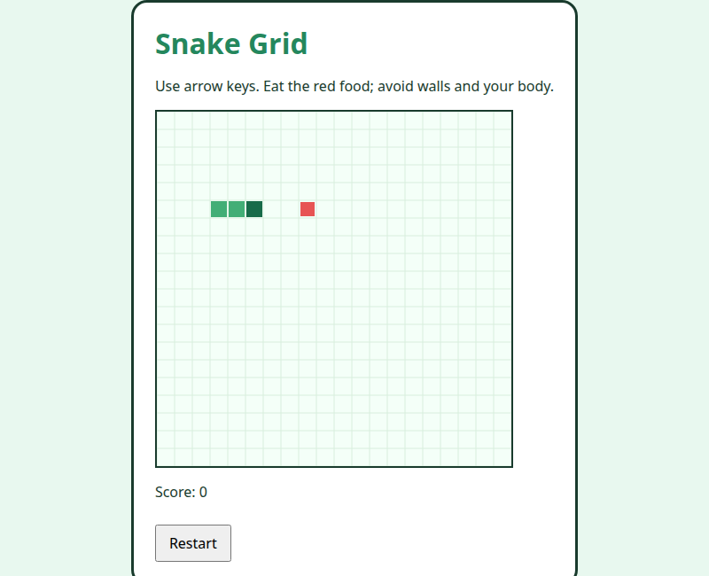

[figure not shown]

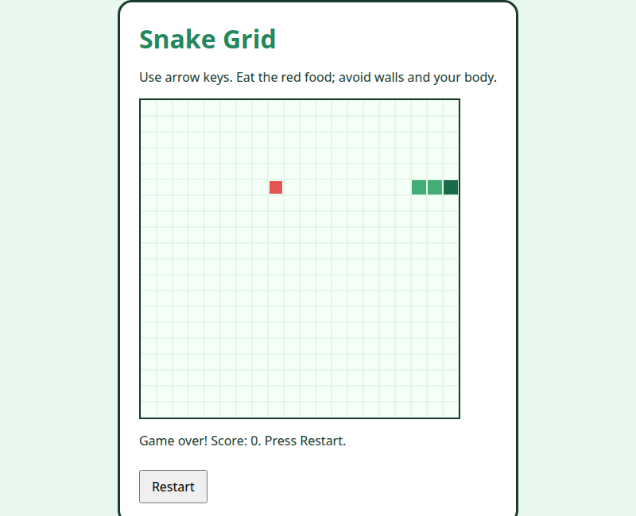

**Read the pictures:** The snake starts with three cells. Reaching food raises the score and leaves the tail in place, so it grows to four cells. A move beyond the right edge ends the game. Restart resets the body, direction, food, and score.

Advanced Study | Game state as data

OPTIONAL DEEPER DIVE

Snake works well because the entire game can be described as data: an array of body cells, a direction, food coordinates, and score. Separating state from drawing makes the program easier to reason about. The screen becomes a picture of the current state rather than the place where the state is stored.

```javascript
const snake = [
  {x: 3, y: 2},
  {x: 2, y: 2}
];
```

**Grid coordinates are data, not pixels.** At 20 pixels per cell, `{ x: 3, y: 2 }` is drawn with its top-left corner at pixel `(60, 40)`. Multiplication happens during drawing; positions stay stored as cells.

**Accept one turn per step.** For a more robust game, allow at most one queued turn between updates, so two fast key presses cannot cause an accidental reversal. Food placement should avoid occupied cells.

## Level-up challenges

Challenge 1

Add obstacles to some grid cells.

1. **Build the scene structure:** Describe the obstacle grid cells and keep them separate from food placement.
2. **Style the scene:** Draw obstacles distinctly from snake and food.
3. **Behavior:** Check obstacle hits and prevent new food from spawning in blocked cells.

Challenge 2

Increase the update speed every five pieces of food.

1. **Build the scene structure:** Reuse the grid, snake, and food counter.
2. **Style the scene:** Keep the cell layout and drawings unchanged while comparing speeds.
3. **Behavior:** Change the update interval every five foods without accumulating timers.

Challenge 3

Add a start screen and a restart key.

1. **Build the scene structure:** Add the start-state instructions and identify the restart key.
2. **Style the scene:** Make ready, playing, and ended states easy to distinguish.
3. **Behavior:** Start intentionally and reset the snake, food, direction, score, and timing on restart.

## Check your development flow

After your exercise or challenge, explain what you built, what you styled, and which game behavior you programmed. If you reused a stage unchanged, say why it already met the task. Record one predicted result and the result you observed, then choose the next small improvement.

# 15 Game Studio

GAME 15 | Design Your Own Game

Design Playtesting Modules

## Overview

Game development is not “write all the code and hope.” Good game designers make a tiny playable version, test it, and improve one rule at a time.

## Learning Objectives

By the end of this chapter, you can:

- turn an idea into game rules
- plan game state before coding
- build a minimum playable version
- test and improve with player feedback

Structure → Style → Behavior

**Build the scene structure → Style the scene → Program game behavior.**

- **Build the scene structure:** Sketch the play area and controls; list the player, objects, goal, and state.
- **Style the scene:** Use readable labels and simple distinguishable shapes for a first playable version.
- **Behavior:** Implement one core action, win/lose rules, and restart, then playtest and repeat the flow.

Use this plan for the examples and exercises below. Reuse parts that already work; change only what the task needs. After each step, predict one result and check it.

Your own project

The planning snippets name jobs a game needs. The complete Catch the Fruit example later in this chapter implements those jobs in one playable page.

## 15.1 Start with one sentence

Describe the game without features: “The player moves a basket to catch falling fruit.” If the sentence is confusing, the first version of the game is probably too complicated.

## 15.2 Identify the game state

List the information the program must remember.

```javascript
// Example: Catch the Fruit
let score = 0;
let lives = 3;
let basketX = 200;
let fruitX = 100;
let fruitY = 0;
let gameOver = false;
```

## 15.3 Write the game loop as a plan

Before writing details, describe the repeating cycle.

```javascript
function loop() {
  updatePlayer();
  updateFruit();
  checkCollisions();
  draw();
  requestAnimationFrame(loop);
}
```

## 15.4 Build the minimum playable version

Your first version needs only enough features to answer: “Can someone play this?” Leave menus, sound, special powers, and artwork until the core rule works.

Minimum playable version

- Player can control something.
- Something changes over time.
- There is a clear goal.
- Success or failure can happen.
- The game can restart.

## 15.5 Playtest like a scientist

Give the game to another person without explaining every rule. Watch where they get confused. Ask what they expected to happen. Change one thing and test again.